# Gemma LMM Summary

The following considerations were used in this document:  
1) Resuls are based on **centralized** distance matrix only, because it generally shows better PVE and doesn’t cheange the results on GWAS.  
2) p-values for likelihood ratio test are used for reporting. Other tests are asymptotically equivalent to LRT.  
3) The following methods used for p-values correction: bonferroni, holm, hochberg, fdr, BY

# Dataset: ‘dataset_1-1stLine_bin’ prediction accuracy summary

| drug | 1 | 0 | 1/1 | 1/0 | 0/1 | 0/0 | precission | recall | f1 | accuracy |
| --- | --- | --- | --- | --- | --- | --- | --- | --- | --- | --- |
| EMB | 102 | 30 | 0.0000 | 0.7727 | 0.0000 | 0.2273 | NaN | 0.0000 | NaN | 0.2273 |
| EMB-nodup | 102 | 30 | 0.0379 | 0.7348 | 0.0000 | 0.2273 | 1.0000 | 0.0490 | 0.0935 | 0.2652 |
| INH | 106 | 26 | 0.0303 | 0.7727 | 0.0000 | 0.1970 | 1.0000 | 0.0377 | 0.0727 | 0.2273 |
| INH-nodup | 106 | 26 | 0.8030 | 0.0000 | 0.0000 | 0.1970 | 1.0000 | 1.0000 | 1.0000 | 1.0000 |
| OFLO | 69 | 63 | 0.5227 | 0.0000 | 0.2576 | 0.2197 | 0.6699 | 1.0000 | 0.8023 | 0.7424 |
| OFLO-nodup | 69 | 63 | 0.5227 | 0.0000 | 0.4242 | 0.0530 | 0.5520 | 1.0000 | 0.7113 | 0.5758 |
| PZA | 28 | 6 | 0.8235 | 0.0000 | 0.0588 | 0.1176 | 0.9333 | 1.0000 | 0.9655 | 0.9412 |
| PZA-nodup | 28 | 6 | 0.8235 | 0.0000 | 0.0294 | 0.1471 | 0.9655 | 1.0000 | 0.9825 | 0.9706 |
| RIF | 106 | 26 | 0.0303 | 0.7727 | 0.0000 | 0.1970 | 1.0000 | 0.0377 | 0.0727 | 0.2273 |
| RIF-nodup | 106 | 26 | 0.7652 | 0.0379 | 0.0000 | 0.1970 | 1.0000 | 0.9528 | 0.9758 | 0.9621 |
| STM | 110 | 22 | 0.0227 | 0.8106 | 0.0000 | 0.1667 | 1.0000 | 0.0273 | 0.0531 | 0.1894 |
| STM-nodup | 110 | 22 | 0.8258 | 0.0076 | 0.0000 | 0.1667 | 1.0000 | 0.9909 | 0.9954 | 0.9924 |

## ‘EMB’ Details

**ROC learning curve**

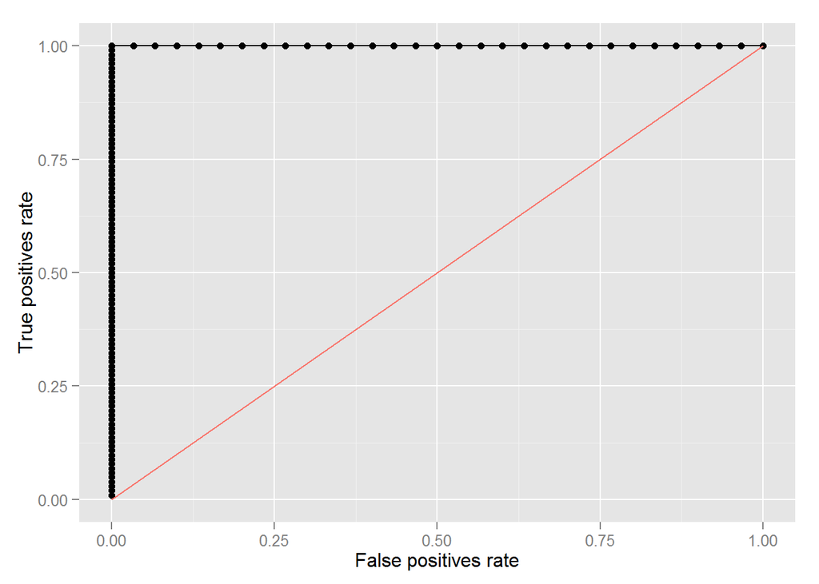

**Manhattan Plot**

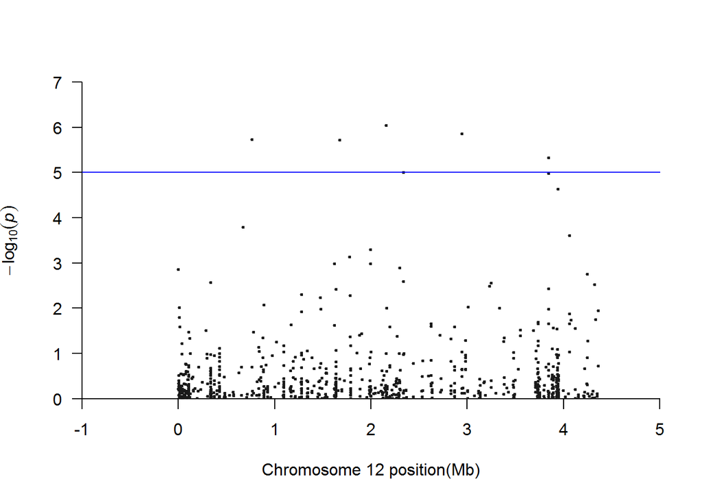

```r
manhattan(test.gwas, cex = .5)
```

**Q-Q Plot**

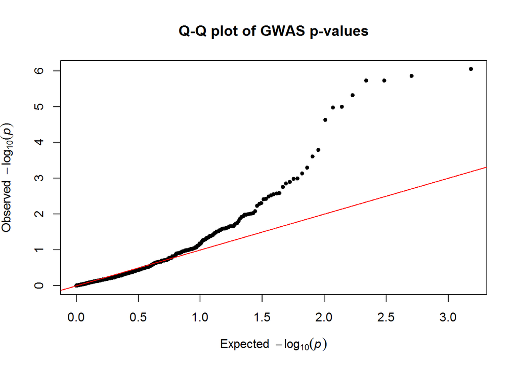

**Significant mutations**

|  | ps | allele1 | allele0 | af | p_lrt | bonferroni | holm | hochberg | fdr | BY |
| --- | --- | --- | --- | --- | --- | --- | --- | --- | --- | --- |
| 1 | 698 | A | G | 0.159 | 0.0013838360 | 1.0000000 | 1.0000000 | 0.9987551 | 0.0661647 | 0.477560 |
| 14 | 7582 | G | A | 0.250 | 0.0097527330 | 1.0000000 | 1.0000000 | 0.9987551 | 0.2343704 | 1.000000 |
| 382 | 333682 | T | C | 0.167 | 0.0026796970 | 1.0000000 | 1.0000000 | 0.9987551 | 0.1063211 | 0.767399 |
| 730 | 673241 | A | G | 0.068 | 0.0001613410 | 0.1234259 | 0.1221351 | 0.1221351 | 0.0137140 | 0.098984 |
| 797 | 761158 | C | T | 0.394 | 0.0000018817 | 0.0014395 | 0.0014357 | 0.0014357 | 0.0003626 | 0.002617 |
| 927 | 888650 | T | C | 0.182 | 0.0084101740 | 1.0000000 | 1.0000000 | 0.9987551 | 0.2297780 | 1.000000 |
| 1321 | 1276437 | T | C | 0.023 | 0.0049811260 | 1.0000000 | 1.0000000 | 0.9987551 | 0.1524225 | 1.000000 |
| 1491 | 1473252 | G | A | 0.386 | 0.0058677060 | 1.0000000 | 1.0000000 | 0.9987551 | 0.1662517 | 1.000000 |
| 1624 | 1619122 | G | C | 0.030 | 0.0010234860 | 0.7829668 | 0.7706850 | 0.7706850 | 0.0572432 | 0.413167 |
| 1670 | 1638194 | T | C | 0.023 | 0.0038355550 | 1.0000000 | 1.0000000 | 0.9987551 | 0.1222583 | 0.882429 |
| 1702 | 1673431 | T | C | 0.235 | 0.0000018961 | 0.0014505 | 0.0014448 | 0.0014448 | 0.0003626 | 0.002617 |
| 1797 | 1779376 | C | G | 0.076 | 0.0007308066 | 0.5590670 | 0.5510282 | 0.5510282 | 0.0465889 | 0.336267 |
| 1801 | 1784411 | G | C | 0.038 | 0.0051817630 | 1.0000000 | 1.0000000 | 0.9987551 | 0.1524634 | 1.000000 |
| 1990 | 1993815 | T | A | 0.098 | 0.0010475880 | 0.8014048 | 0.7877862 | 0.7877862 | 0.0572432 | 0.413167 |
| 1991 | 1994349 | C | T | 0.038 | 0.0005036435 | 0.3852873 | 0.3802508 | 0.3802508 | 0.0350261 | 0.252810 |
| 2149 | 2155175 | C | G | 0.303 | 0.0000009003 | 0.0006887 | 0.0006887 | 0.0006887 | 0.0003626 | 0.002617 |
| 2375 | 2300245 | A | G | 0.129 | 0.0012689250 | 0.9707276 | 0.9529627 | 0.9529627 | 0.0647152 | 0.467098 |
| 2492 | 2339283 | C | A | 0.023 | 0.0025751320 | 1.0000000 | 1.0000000 | 0.9987551 | 0.1063211 | 0.767399 |
| 2504 | 2339613 | G | A | 0.030 | 0.0000099875 | 0.0076405 | 0.0075905 | 0.0075905 | 0.0011587 | 0.008364 |
| 3020 | 2944749 | T | C | 0.015 | 0.0000013944 | 0.0010667 | 0.0010653 | 0.0010653 | 0.0003626 | 0.002617 |
| 3085 | 3007156 | C | G | 0.038 | 0.0093987640 | 1.0000000 | 1.0000000 | 0.9987551 | 0.2343704 | 1.000000 |
| 3249 | 3232713 | A | G | 0.023 | 0.0032505830 | 1.0000000 | 1.0000000 | 0.9987551 | 0.1130316 | 0.815834 |
| 3259 | 3246903 | C | T | 0.053 | 0.0027796370 | 1.0000000 | 1.0000000 | 0.9987551 | 0.1063211 | 0.767399 |
| 3326 | 3336597 | A | T | 0.189 | 0.0099336490 | 1.0000000 | 1.0000000 | 0.9987551 | 0.2343704 | 1.000000 |
| 3778 | 3842469 | T | C | 0.015 | 0.0000047703 | 0.0036492 | 0.0036302 | 0.0036302 | 0.0007298 | 0.005268 |
| 3785 | 3842662 | C | A | 0.030 | 0.0000106029 | 0.0081112 | 0.0080476 | 0.0080476 | 0.0011587 | 0.008364 |
| 3799 | 3842747 | A | C | 0.038 | 0.0037578840 | 1.0000000 | 1.0000000 | 0.9987551 | 0.1222583 | 0.882429 |
| 3982 | 3943332 | C | G | 0.045 | 0.0000233247 | 0.0178434 | 0.0176801 | 0.0176801 | 0.0022304 | 0.016099 |
| 4117 | 4060767 | T | C | 0.326 | 0.0002472263 | 0.1891281 | 0.1869031 | 0.1869031 | 0.0189128 | 0.136508 |
| 4278 | 4248181 | G | A | 0.205 | 0.0017482030 | 1.0000000 | 1.0000000 | 0.9987551 | 0.0786691 | 0.567814 |
| 4358 | 4322778 | C | G | 0.189 | 0.0030034030 | 1.0000000 | 1.0000000 | 0.9987551 | 0.1094097 | 0.789691 |

## ‘EMB-nodup’ Details

**ROC learning curve**

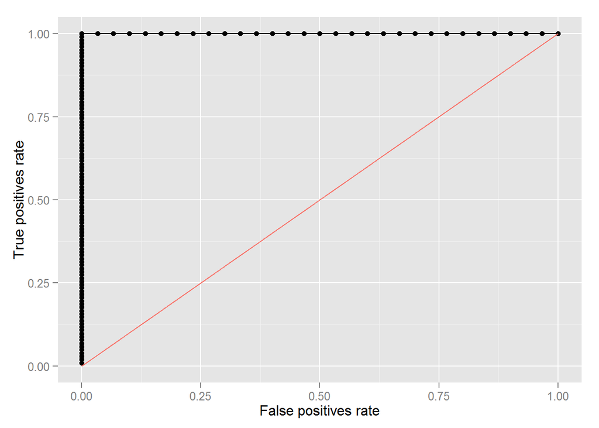

**Manhattan Plot**

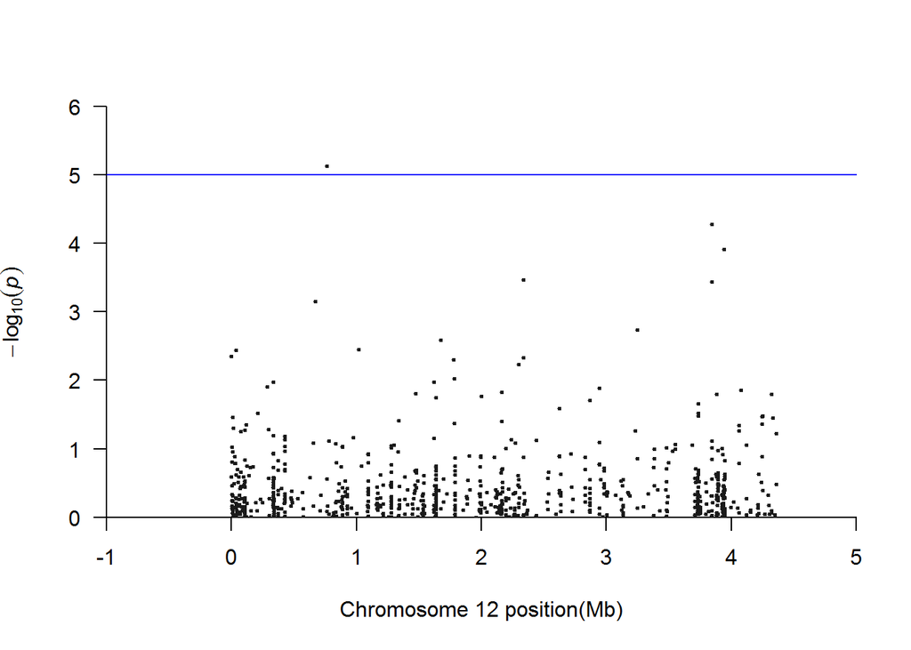

```r
manhattan(test.gwas, cex = .5)
```

**Q-Q Plot**

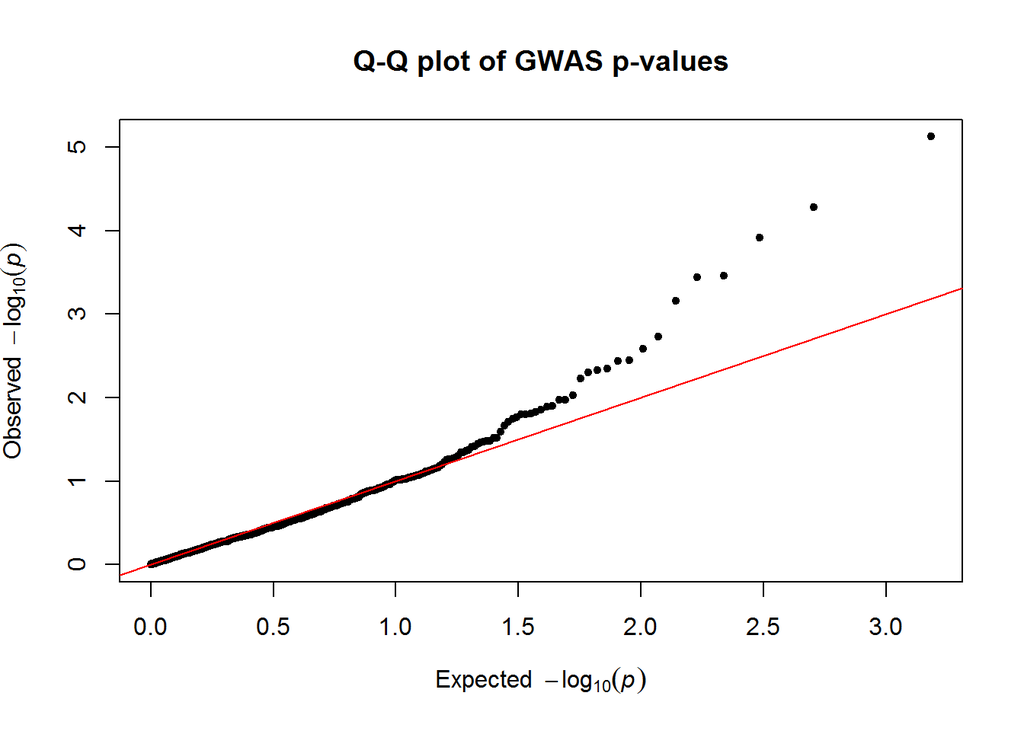

**Significant mutations**

|  | ps | allele1 | allele0 | af | p_lrt | bonferroni | holm | hochberg | fdr | BY |
| --- | --- | --- | --- | --- | --- | --- | --- | --- | --- | --- |
| 1 | 698 | A | G | 0.159 | 0.004506627 | 1.000000 | 1.000000 | 0.999169 | 0.295169 | 1.00000 |
| 31 | 35978 | A | G | 0.076 | 0.003652493 | 1.000000 | 1.000000 | 0.999169 | 0.279050 | 1.00000 |
| 182 | 673241 | A | G | 0.068 | 0.000698112 | 0.533357 | 0.529867 | 0.529867 | 0.088893 | 0.64149 |
| 186 | 761158 | C | T | 0.394 | 0.000007466 | 0.005704 | 0.005704 | 0.005704 | 0.005704 | 0.04116 |
| 228 | 1020196 | C | T | 0.061 | 0.003538508 | 1.000000 | 1.000000 | 0.999169 | 0.279050 | 1.00000 |
| 366 | 1673431 | T | C | 0.235 | 0.002600205 | 1.000000 | 1.000000 | 0.999169 | 0.248320 | 1.00000 |
| 371 | 1779376 | C | G | 0.076 | 0.005022517 | 1.000000 | 1.000000 | 0.999169 | 0.295169 | 1.00000 |
| 373 | 1784411 | G | C | 0.038 | 0.009391733 | 1.000000 | 1.000000 | 0.999169 | 0.474474 | 1.00000 |
| 475 | 2300245 | A | G | 0.129 | 0.005872838 | 1.000000 | 1.000000 | 0.999169 | 0.320489 | 1.00000 |
| 483 | 2339283 | C | A | 0.023 | 0.004666277 | 1.000000 | 1.000000 | 0.999169 | 0.295169 | 1.00000 |
| 485 | 2339613 | G | A | 0.030 | 0.000344124 | 0.262911 | 0.261878 | 0.261878 | 0.055682 | 0.40183 |
| 565 | 3246903 | C | T | 0.053 | 0.001840980 | 1.000000 | 1.000000 | 0.999169 | 0.200930 | 1.00000 |
| 641 | 3842469 | T | C | 0.015 | 0.000052521 | 0.040126 | 0.040074 | 0.040074 | 0.020063 | 0.14478 |
| 642 | 3842662 | C | A | 0.030 | 0.000364413 | 0.278411 | 0.276954 | 0.276954 | 0.055682 | 0.40183 |
| 710 | 3943332 | C | G | 0.045 | 0.000121399 | 0.092749 | 0.092506 | 0.092506 | 0.030916 | 0.22310 |

## ‘INH’ Details

**Manhattan Plot**

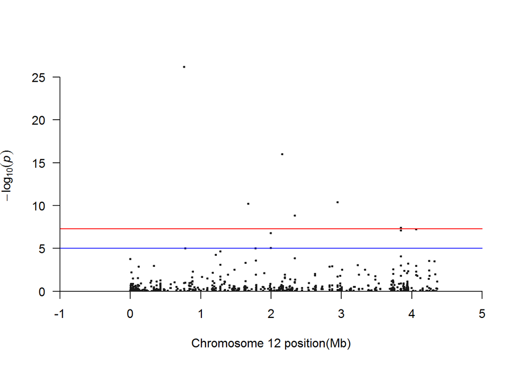

```r
manhattan(test.gwas, cex = .5)
```

**Q-Q Plot**

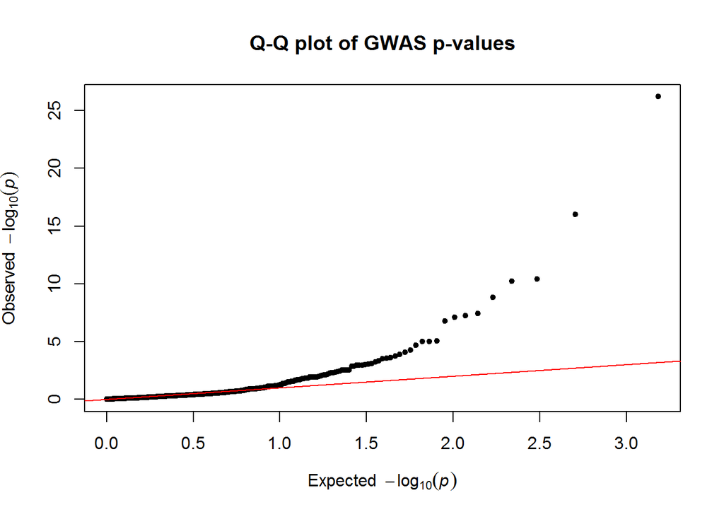

**Significant mutations**

|  | ps | allele1 | allele0 | af | p_lrt | bonferroni | holm | hochberg | fdr | BY |
| --- | --- | --- | --- | --- | --- | --- | --- | --- | --- | --- |
| 1 | 698 | A | G | 0.159 | 0.00017915670000000000 | 0.13705487550000001 | 0.13418836830000000 | 0.13418836830000000 | 0.00806205150000000 | 0.0581898315096651 |
| 25 | 14105 | G | C | 0.023 | 0.00595858999999999972 | 1.00000000000000000 | 1.00000000000000000 | 0.99979070000000003 | 0.11395803374999998 | 0.8225200227367973 |
| 180 | 119102 | G | A | 0.015 | 0.00136243200000000001 | 1.00000000000000000 | 1.00000000000000000 | 0.99979070000000003 | 0.03474201600000000 | 0.2507590105751730 |
| 382 | 333682 | T | C | 0.167 | 0.00113445100000000008 | 0.86785501500000006 | 0.83835928900000001 | 0.83835928900000001 | 0.03138087375000000 | 0.2264991430702933 |
| 797 | 761158 | C | T | 0.394 | 0.00000000000000000000 | 0.00000000000000000 | 0.00000000000000000 | 0.00000000000000000 | 0.00000000000000000 | 0.0000000000000000 |
| 830 | 781690 | G | A | 0.492 | 0.00000989257100000000 | 0.00756781681500000 | 0.00746889110500000 | 0.00746889110500000 | 0.00064291811250000 | 0.0046404189604702 |
| 927 | 888650 | T | C | 0.182 | 0.00486009500000000004 | 1.00000000000000000 | 1.00000000000000000 | 0.99979070000000003 | 0.09749685692307694 | 0.7037074468050436 |
| 1224 | 1169970 | A | G | 0.038 | 0.00709667500000000021 | 1.00000000000000000 | 1.00000000000000000 | 0.99979070000000003 | 0.13241357012195124 | 0.9557273772053637 |
| 1268 | 1212437 | C | A | 0.348 | 0.00005700591000000000 | 0.04360952115000000 | 0.04286844432000000 | 0.04286844432000000 | 0.00311496579642857 | 0.0224830286500338 |
| 1320 | 1276428 | C | T | 0.030 | 0.00083014510000000005 | 0.63506100150000000 | 0.61679780930000006 | 0.61679780930000006 | 0.02761134789130434 | 0.1992916668356369 |
| 1321 | 1276437 | T | C | 0.023 | 0.00002186717000000000 | 0.01672838505000000 | 0.01646597901000000 | 0.01646597901000000 | 0.00128679885000000 | 0.0092877859026739 |
| 1500 | 1481191 | C | A | 0.235 | 0.00303358699999999992 | 1.00000000000000000 | 1.00000000000000000 | 0.99979070000000003 | 0.06992178750000000 | 0.5046776287002890 |
| 1670 | 1638194 | T | C | 0.023 | 0.00046461560000000002 | 0.35543093400000003 | 0.34613862200000001 | 0.34613862200000001 | 0.01692528257142857 | 0.1221623728259364 |
| 1702 | 1673431 | T | C | 0.235 | 0.00000000006287214000 | 0.00000004809718710 | 0.00000004790857068 | 0.00000004790857068 | 0.00000001202429678 | 0.0000000867883073 |
| 1797 | 1779376 | C | G | 0.076 | 0.00001008499000000000 | 0.00771501735000000 | 0.00760408246000000 | 0.00760408246000000 | 0.00064291811250000 | 0.0046404189604702 |
| 1801 | 1784411 | G | C | 0.038 | 0.00024537149999999999 | 0.18770919749999998 | 0.18353788199999999 | 0.18353788199999999 | 0.01042828875000000 | 0.0752687284739667 |
| 1917 | 1905524 | C | T | 0.023 | 0.00767485400000000005 | 1.00000000000000000 | 1.00000000000000000 | 0.99979070000000003 | 0.13654100720930235 | 0.9855181654035912 |
| 1990 | 1993815 | T | A | 0.098 | 0.00000866395400000000 | 0.00662792481000000 | 0.00654994922400000 | 0.00654994922400000 | 0.00064291811250000 | 0.0046404189604702 |
| 1991 | 1994349 | C | T | 0.038 | 0.00000016285580000000 | 0.00012458468700000 | 0.00012328184060000 | 0.00012328184060000 | 0.00001384274300000 | 0.0000999133883977 |
| 2149 | 2155175 | C | G | 0.303 | 0.00000000000000009472 | 0.00000000000007246 | 0.00000000000007236 | 0.00000000000007236 | 0.00000000000003623 | 0.0000000000002615 |
| 2492 | 2339283 | C | A | 0.023 | 0.00013810569999999999 | 0.10565086049999999 | 0.10357927499999998 | 0.10357927499999998 | 0.00660317878125000 | 0.0476600603096040 |
| 2504 | 2339613 | G | A | 0.030 | 0.00000000144677400000 | 0.00000110678211000 | 0.00000110099501400 | 0.00000110099501400 | 0.00000022135642200 | 0.0000015976941973 |
| 2734 | 2626688 | C | A | 0.015 | 0.00930649700000000038 | 1.00000000000000000 | 1.00000000000000000 | 0.99979070000000003 | 0.15821044900000000 | 1.0000000000000000 |
| 2882 | 2828832 | T | G | 0.250 | 0.00132669800000000007 | 1.00000000000000000 | 0.97777642599999992 | 0.97777642599999992 | 0.03474201600000000 | 0.2507590105751730 |
| 2920 | 2866873 | C | G | 0.348 | 0.00114858100000000008 | 0.87866446500000006 | 0.84765277800000016 | 0.84765277800000016 | 0.03138087375000000 | 0.2264991430702933 |
| 3020 | 2944749 | T | C | 0.015 | 0.00000000003962640000 | 0.00000003031419600 | 0.00000003023494320 | 0.00000003023494320 | 0.00000001010473200 | 0.0000000729333784 |
| 3085 | 3007156 | C | G | 0.038 | 0.00306185699999999986 | 1.00000000000000000 | 1.00000000000000000 | 0.99979070000000003 | 0.06992178750000000 | 0.5046776287002890 |
| 3249 | 3232713 | A | G | 0.023 | 0.00089174540000000002 | 0.68218523100000006 | 0.66167508679999998 | 0.66167508679999998 | 0.02842438462500000 | 0.2051599586153308 |
| 3326 | 3336597 | A | T | 0.189 | 0.00310763500000000008 | 1.00000000000000000 | 1.00000000000000000 | 0.99979070000000003 | 0.06992178750000000 | 0.5046776287002890 |
| 3646 | 3735880 | G | A | 0.015 | 0.00898744200000000000 | 1.00000000000000000 | 1.00000000000000000 | 0.99979070000000003 | 0.15625893477272729 | 1.0000000000000000 |
| 3648 | 3735984 | G | C | 0.144 | 0.00283286900000000001 | 1.00000000000000000 | 1.00000000000000000 | 0.99979070000000003 | 0.06990789629032258 | 0.5045773654917750 |
| 3778 | 3842469 | T | C | 0.015 | 0.00000003849672000000 | 0.00002944999080000 | 0.00002925750720000 | 0.00002925750720000 | 0.00000490833180000 | 0.0000354270870678 |
| 3785 | 3842662 | C | A | 0.030 | 0.00000008063070000000 | 0.00006168248550000 | 0.00006111807060000 | 0.00006111807060000 | 0.00000771031068750 | 0.0000556510560361 |
| 3799 | 3842747 | A | C | 0.038 | 0.00099787529999999995 | 0.76337460449999994 | 0.73942559730000001 | 0.73942559730000001 | 0.03053498418000000 | 0.2203937278972343 |
| 3805 | 3843156 | G | A | 0.023 | 0.00008558095000000000 | 0.06546942675000000 | 0.06427129345000000 | 0.06427129345000000 | 0.00436462845000000 | 0.0315027749584322 |
| 3904 | 3895578 | A | C | 0.212 | 0.00400603600000000015 | 1.00000000000000000 | 1.00000000000000000 | 0.99979070000000003 | 0.08512826500000001 | 0.6144341048999900 |
| 3946 | 3930619 | A | C | 0.038 | 0.00755164100000000043 | 1.00000000000000000 | 1.00000000000000000 | 0.99979070000000003 | 0.13654100720930235 | 0.9855181654035912 |
| 3993 | 3946429 | G | C | 0.015 | 0.00059795319999999999 | 0.45743419800000001 | 0.44487718079999999 | 0.44487718079999999 | 0.02079246354545455 | 0.1500746987762177 |
| 4011 | 3947508 | C | G | 0.015 | 0.00457777099999999958 | 1.00000000000000000 | 1.00000000000000000 | 0.99979070000000003 | 0.09464850851351352 | 0.6831487944529322 |
| 4111 | 4060279 | G | A | 0.068 | 0.00109485799999999999 | 0.83756637000000000 | 0.81019492000000004 | 0.81019492000000004 | 0.03138087375000000 | 0.2264991430702933 |
| 4116 | 4060645 | A | G | 0.038 | 0.00497042799999999983 | 1.00000000000000000 | 1.00000000000000000 | 0.99979070000000003 | 0.09749685692307694 | 0.7037074468050436 |
| 4117 | 4060767 | T | C | 0.326 | 0.00000005972181000000 | 0.00004568718465000 | 0.00004532885379000 | 0.00004532885379000 | 0.00000652674066429 | 0.0000471083494768 |
| 4274 | 4247607 | G | A | 0.121 | 0.00028646230000000002 | 0.21914365950000000 | 0.21398733809999998 | 0.21398733809999998 | 0.01153387681578947 | 0.0832485811538195 |
| 4278 | 4248181 | G | A | 0.205 | 0.00365857200000000013 | 1.00000000000000000 | 1.00000000000000000 | 0.99979070000000003 | 0.07996593085714286 | 0.5771736937044712 |
| 4358 | 4322778 | C | G | 0.189 | 0.00030649749999999998 | 0.23447058750000002 | 0.22864713500000003 | 0.22864713500000003 | 0.01172352937500000 | 0.0846174449555252 |

## ‘INH-nodup’ Details

**Manhattan Plot**

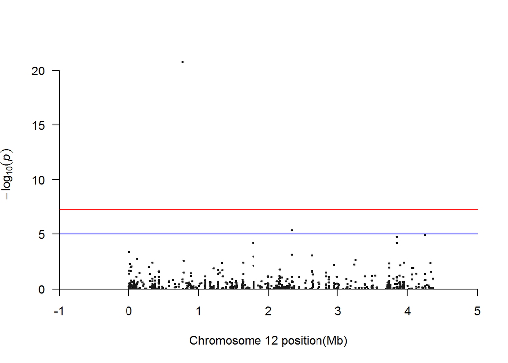

```r
manhattan(test.gwas, cex = .5)
```

**Q-Q Plot**

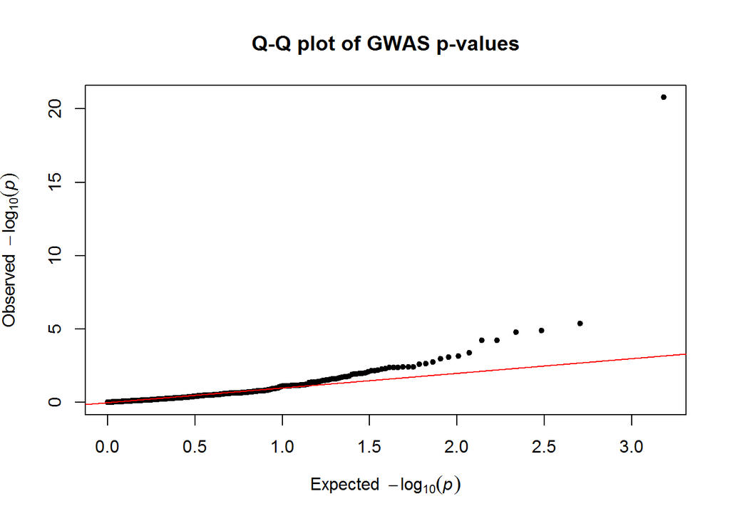

**Significant mutations**

|  | ps | allele1 | allele0 | af | p_lrt | bonferroni | holm | hochberg | fdr | BY |
| --- | --- | --- | --- | --- | --- | --- | --- | --- | --- | --- |
| 1 | 698 | A | G | 0.159 | 0.000428059 | 0.32660886439999997632 | 0.32404051159999996967 | 0.32404051159999996967 | 0.04665840920000000058 | 0.33664643482903700011 |
| 18 | 14105 | G | C | 0.023 | 0.004942531 | 1.00000000000000000000 | 1.00000000000000000000 | 0.99922759999999999359 | 0.18855755764999998503 | 1.00000000000000000000 |
| 31 | 35978 | A | G | 0.076 | 0.008447028 | 1.00000000000000000000 | 1.00000000000000000000 | 0.99922759999999999359 | 0.25780329456000000699 | 1.00000000000000000000 |
| 81 | 119102 | G | A | 0.015 | 0.001755979 | 1.00000000000000000000 | 1.00000000000000000000 | 0.99922759999999999359 | 0.12180108881818180189 | 0.87881055123790630113 |
| 107 | 333682 | T | C | 0.167 | 0.003786033 | 1.00000000000000000000 | 1.00000000000000000000 | 0.99922759999999999359 | 0.17614477447368420693 | 1.00000000000000000000 |
| 186 | 761158 | C | T | 0.394 | 0.000000000 | 0.00000000000000000128 | 0.00000000000000000128 | 0.00000000000000000128 | 0.00000000000000000128 | 0.00000000000000000922 |
| 189 | 781690 | G | A | 0.492 | 0.002533614 | 1.00000000000000000000 | 1.00000000000000000000 | 0.99922759999999999359 | 0.14870365246153846583 | 1.00000000000000000000 |
| 284 | 1333675 | T | G | 0.371 | 0.004251937 | 1.00000000000000000000 | 1.00000000000000000000 | 0.99922759999999999359 | 0.17614477447368420693 | 1.00000000000000000000 |
| 360 | 1638194 | T | C | 0.023 | 0.003897491 | 1.00000000000000000000 | 1.00000000000000000000 | 0.99922759999999999359 | 0.17614477447368420693 | 1.00000000000000000000 |
| 370 | 1779376 | C | G | 0.076 | 0.000061493 | 0.04691938789999999804 | 0.04661192139999999901 | 0.04661192139999999901 | 0.00781989798333333243 | 0.05642157162992052916 |
| 371 | 1782438 | C | A | 0.023 | 0.007322313 | 1.00000000000000000000 | 1.00000000000000000000 | 0.99922759999999999359 | 0.23278853412500005726 | 1.00000000000000000000 |
| 372 | 1784411 | G | C | 0.038 | 0.001117701 | 0.85280586300000005284 | 0.84274655399999998107 | 0.84274655399999998107 | 0.08528058630000000251 | 0.61531041949936471358 |
| 482 | 2339283 | C | A | 0.023 | 0.000731276 | 0.55796343540000004069 | 0.55284450480000002504 | 0.55284450480000002504 | 0.06974542942500000509 | 0.50322226076980058895 |
| 484 | 2339613 | G | A | 0.030 | 0.000004332 | 0.00330528395400000010 | 0.00330095199599999981 | 0.00330095199599999981 | 0.00165264197700000005 | 0.01192402482521546028 |
| 504 | 2626610 | A | G | 0.053 | 0.000845743 | 0.64530175639999998172 | 0.63853581399999992385 | 0.63853581399999992385 | 0.07170019515555554890 | 0.51732614740889981686 |
| 533 | 2944749 | T | C | 0.015 | 0.006379440 | 1.00000000000000000000 | 1.00000000000000000000 | 0.99922759999999999359 | 0.22125057818181817493 | 1.00000000000000000000 |
| 563 | 3232713 | A | G | 0.023 | 0.005645661 | 1.00000000000000000000 | 1.00000000000000000000 | 0.99922759999999999359 | 0.20512568300000003085 | 1.00000000000000000000 |
| 564 | 3246903 | C | T | 0.053 | 0.002237181 | 1.00000000000000000000 | 1.00000000000000000000 | 0.99922759999999999359 | 0.14224742525000000359 | 1.00000000000000000000 |
| 615 | 3735880 | G | A | 0.015 | 0.004386305 | 1.00000000000000000000 | 1.00000000000000000000 | 0.99922759999999999359 | 0.17614477447368420693 | 1.00000000000000000000 |
| 640 | 3842469 | T | C | 0.015 | 0.000016840 | 0.01284919468000000030 | 0.01279867359999999933 | 0.01279867359999999933 | 0.00321229867000000007 | 0.02317714884419070850 |
| 641 | 3842662 | C | A | 0.030 | 0.000060960 | 0.04651265548999999194 | 0.04626881457000000392 | 0.04626881457000000392 | 0.00781989798333333243 | 0.05642157162992052916 |
| 675 | 3895578 | A | C | 0.212 | 0.006764388 | 1.00000000000000000000 | 1.00000000000000000000 | 0.99922759999999999359 | 0.22440121930434778208 | 1.00000000000000000000 |
| 714 | 3946429 | G | C | 0.015 | 0.003937839 | 1.00000000000000000000 | 1.00000000000000000000 | 0.99922759999999999359 | 0.17614477447368420693 | 1.00000000000000000000 |
| 747 | 4247607 | G | A | 0.121 | 0.000012447 | 0.00949719834000000047 | 0.00947230398000000091 | 0.00947230398000000091 | 0.00316573278000000001 | 0.02284116994731179642 |
| 758 | 4322778 | C | G | 0.189 | 0.004242027 | 1.00000000000000000000 | 1.00000000000000000000 | 0.99922759999999999359 | 0.17614477447368420693 | 1.00000000000000000000 |

## ‘OFLO’ Details

**ROC learning curve**

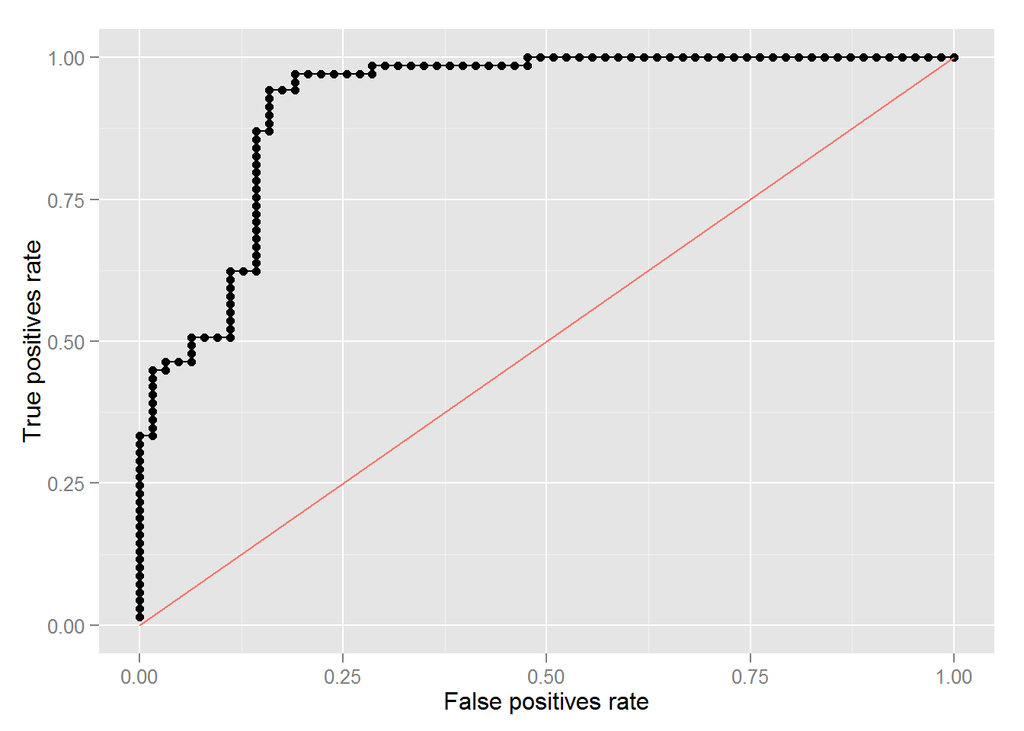

**Manhattan Plot**

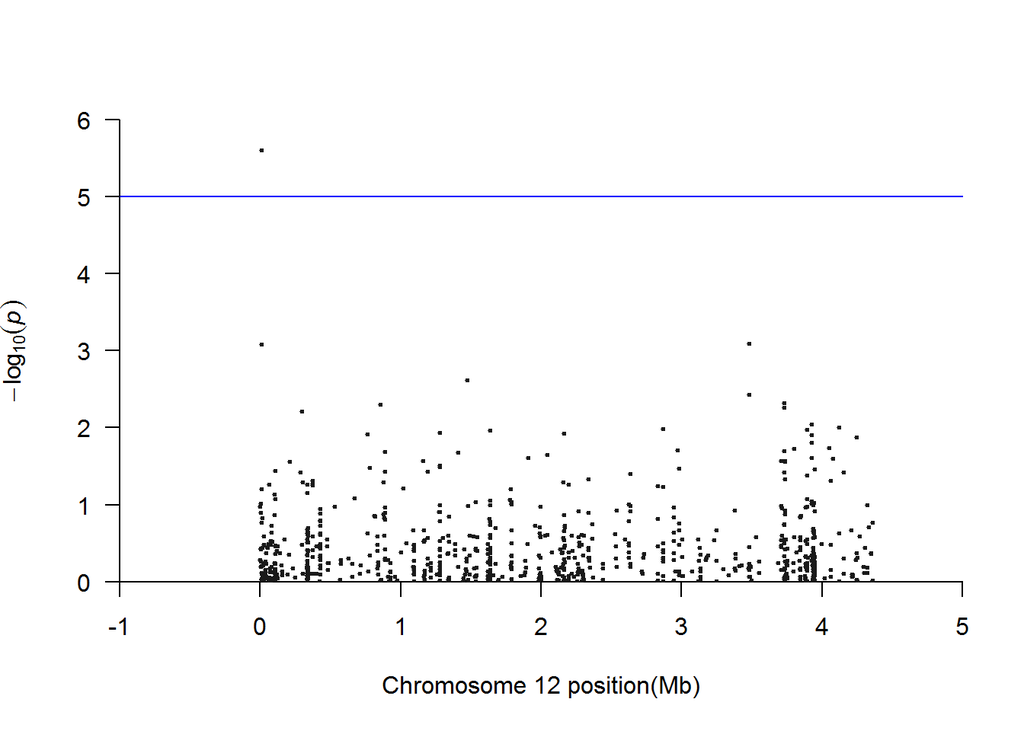

```r
manhattan(test.gwas, cex = .5)
```

**Q-Q Plot**

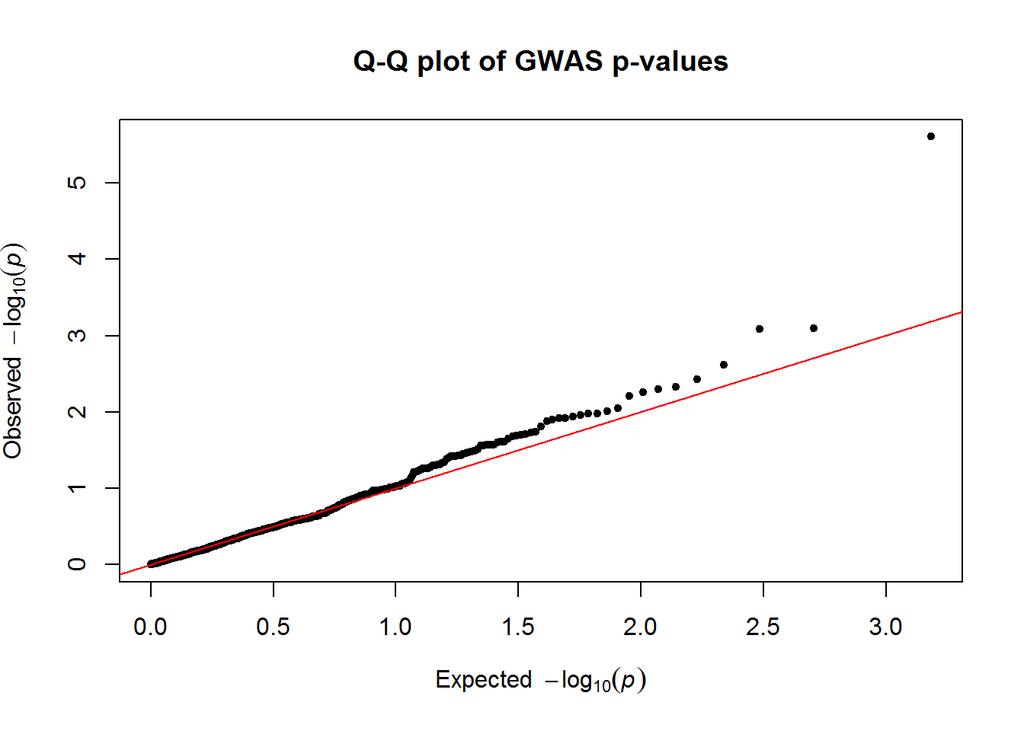

**Significant mutations**

|  | ps | allele1 | allele0 | af | p_lrt | bonferroni | holm | hochberg | fdr | BY |
| --- | --- | --- | --- | --- | --- | --- | --- | --- | --- | --- |
| 11 | 7570 | T | C | 0.174 | 0.000828806 | 0.634037 | 0.632379 | 0.632379 | 0.211346 | 1.0000 |
| 14 | 7582 | G | A | 0.250 | 0.000002481 | 0.001898 | 0.001898 | 0.001898 | 0.001898 | 0.0137 |
| 334 | 295731 | C | T | 0.189 | 0.006149816 | 1.000000 | 1.000000 | 0.999275 | 0.522734 | 1.0000 |
| 896 | 854607 | T | C | 0.470 | 0.005035181 | 1.000000 | 1.000000 | 0.999275 | 0.522734 | 1.0000 |
| 1491 | 1473252 | G | A | 0.386 | 0.002424576 | 1.000000 | 1.000000 | 0.999275 | 0.463700 | 1.0000 |
| 3440 | 3481957 | A | G | 0.409 | 0.000807786 | 0.617956 | 0.617149 | 0.617149 | 0.211346 | 1.0000 |
| 3441 | 3481990 | A | G | 0.439 | 0.003706613 | 1.000000 | 1.000000 | 0.999275 | 0.522734 | 1.0000 |
| 3624 | 3730787 | A | G | 0.159 | 0.005527961 | 1.000000 | 1.000000 | 0.999275 | 0.522734 | 1.0000 |
| 3625 | 3730813 | G | A | 0.485 | 0.004763877 | 1.000000 | 1.000000 | 0.999275 | 0.522734 | 1.0000 |
| 3932 | 3927717 | A | G | 0.250 | 0.009063915 | 1.000000 | 1.000000 | 0.999275 | 0.530227 | 1.0000 |
| 4156 | 4121290 | A | C | 0.174 | 0.009800272 | 1.000000 | 1.000000 | 0.999275 | 0.530227 | 1.0000 |

## ‘OFLO-nodup’ Details

**ROC learning curve**

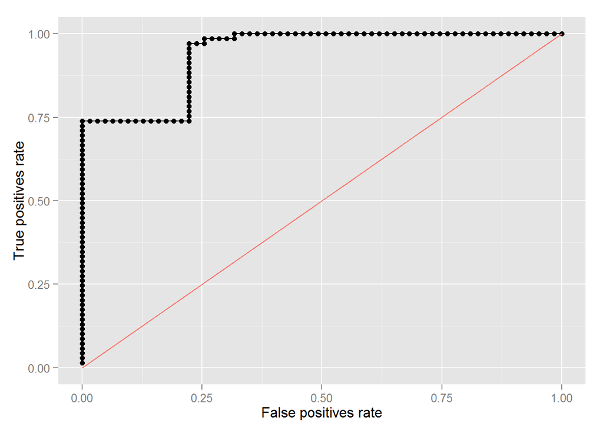

**Manhattan Plot**

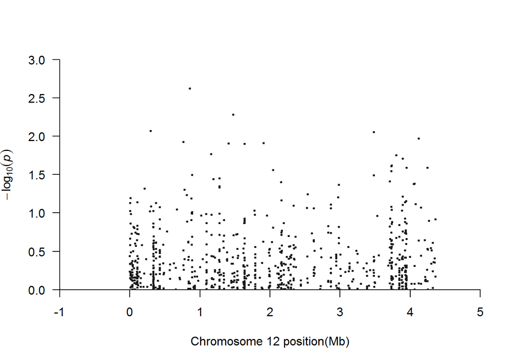

```r
manhattan(test.gwas, cex = .5)
```

**Q-Q Plot**

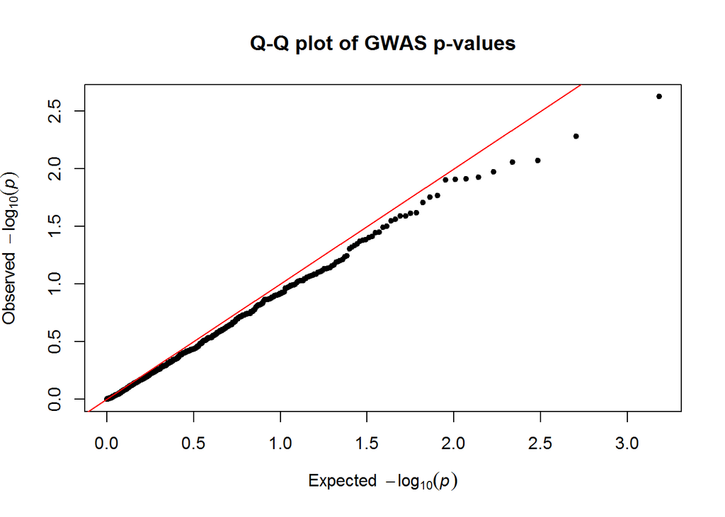

**Significant mutations**

|  | ps | allele1 | allele0 | af | p_lrt | bonferroni | holm | hochberg | fdr | BY |
| --- | --- | --- | --- | --- | --- | --- | --- | --- | --- | --- |
| 94 | 295731 | C | T | 0.189 | 0.008466 | 1 | 1 | 0.9999 | 0.9999 | 1 |
| 198 | 854607 | T | C | 0.470 | 0.002370 | 1 | 1 | 0.9999 | 0.9999 | 1 |
| 305 | 1473252 | G | A | 0.386 | 0.005243 | 1 | 1 | 0.9999 | 0.9999 | 1 |
| 579 | 3481957 | A | G | 0.409 | 0.008779 | 1 | 1 | 0.9999 | 0.9999 | 1 |

## ‘PZA’ Details

**ROC learning curve**

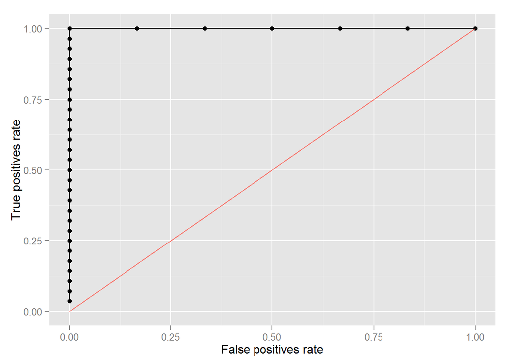

**Manhattan Plot**

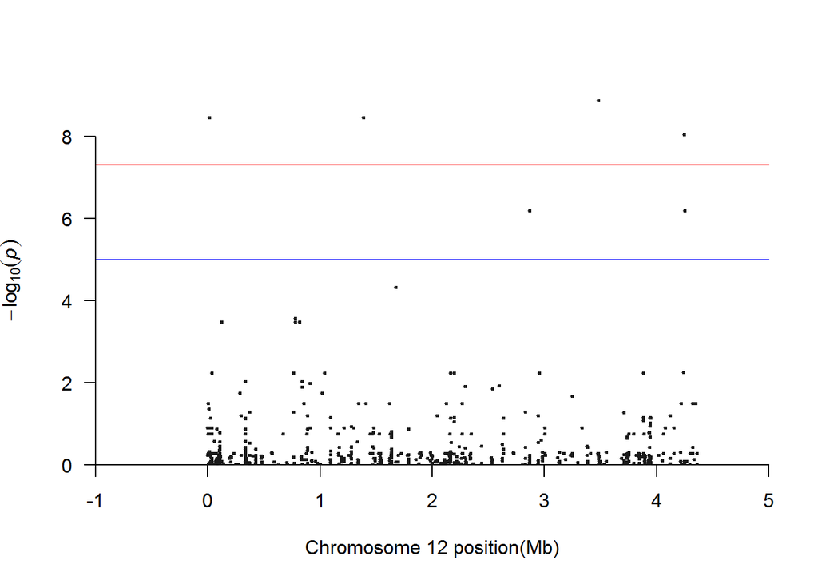

```r
manhattan(test.gwas, cex = .5)
```

**Q-Q Plot**

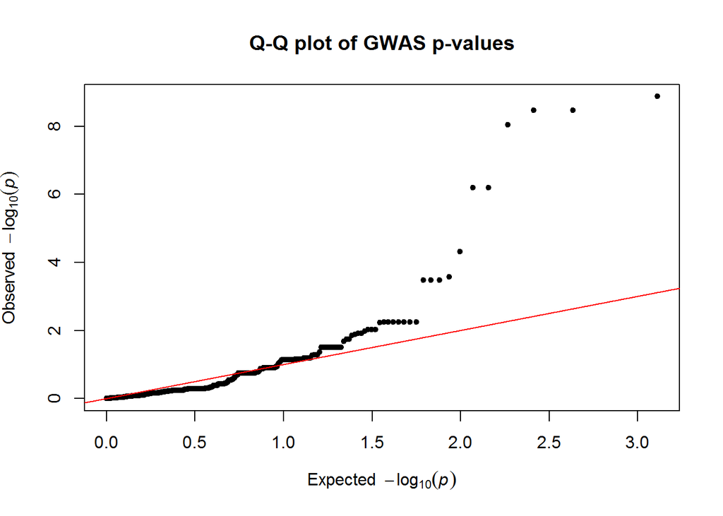

**Significant mutations**

|  | ps | allele1 | allele0 | af | p_lrt | bonferroni | holm | hochberg | fdr | BY |
| --- | --- | --- | --- | --- | --- | --- | --- | --- | --- | --- |
| 25 | 14658 | A | G | 0.029 | 0.000000003385 | 0.0000021870 | 0.0000021836 | 0.0000021802 | 0.000000729 | 0.000005139 |
| 51 | 35978 | A | G | 0.118 | 0.005728064000 | 1.0000000000 | 1.0000000000 | 0.9998193000 | 0.198032082 | 1.000000000 |
| 150 | 122350 | G | A | 0.059 | 0.000331768500 | 0.2143224510 | 0.2116683030 | 0.2110047660 | 0.019483859 | 0.137337612 |
| 328 | 336332 | C | G | 0.029 | 0.009343867000 | 1.0000000000 | 1.0000000000 | 0.9998193000 | 0.274369913 | 1.000000000 |
| 329 | 336344 | G | A | 0.029 | 0.009343867000 | 1.0000000000 | 1.0000000000 | 0.9998193000 | 0.274369913 | 1.000000000 |
| 667 | 764825 | T | G | 0.118 | 0.005728064000 | 1.0000000000 | 1.0000000000 | 0.9998193000 | 0.198032082 | 1.000000000 |
| 691 | 781690 | G | A | 0.500 | 0.000270065800 | 0.1744625068 | 0.1725720462 | 0.1725720462 | 0.019483859 | 0.137337612 |
| 692 | 781825 | G | A | 0.059 | 0.000331768500 | 0.2143224510 | 0.2116683030 | 0.2110047660 | 0.019483859 | 0.137337612 |
| 718 | 817530 | T | G | 0.059 | 0.000331768500 | 0.2143224510 | 0.2116683030 | 0.2110047660 | 0.019483859 | 0.137337612 |
| 740 | 839980 | T | C | 0.029 | 0.009343867000 | 1.0000000000 | 1.0000000000 | 0.9998193000 | 0.274369913 | 1.000000000 |
| 884 | 1040013 | C | T | 0.118 | 0.005728064000 | 1.0000000000 | 1.0000000000 | 0.9998193000 | 0.198032082 | 1.000000000 |
| 1162 | 1385345 | T | C | 0.029 | 0.000000003385 | 0.0000021870 | 0.0000021836 | 0.0000021802 | 0.000000729 | 0.000005139 |
| 1382 | 1673431 | T | C | 0.235 | 0.000047430940 | 0.0306403872 | 0.0303558016 | 0.0303558016 | 0.004377198 | 0.030853946 |
| 1767 | 2163338 | A | G | 0.118 | 0.005728064000 | 1.0000000000 | 1.0000000000 | 0.9998193000 | 0.198032082 | 1.000000000 |
| 1857 | 2196976 | G | C | 0.353 | 0.005824473000 | 1.0000000000 | 1.0000000000 | 0.9998193000 | 0.198032082 | 1.000000000 |
| 2392 | 2866873 | C | G | 0.353 | 0.000000643422 | 0.0004156505 | 0.0004130769 | 0.0004124334 | 0.000069275 | 0.000488305 |
| 2493 | 2955148 | T | C | 0.118 | 0.005728064000 | 1.0000000000 | 1.0000000000 | 0.9998193000 | 0.198032082 | 1.000000000 |
| 2832 | 3482714 | A | G | 0.324 | 0.000000001328 | 0.0000008578 | 0.0000008578 | 0.0000008578 | 0.000000729 | 0.000005139 |
| 3200 | 3884024 | C | T | 0.118 | 0.005728064000 | 1.0000000000 | 1.0000000000 | 0.9998193000 | 0.198032082 | 1.000000000 |
| 3553 | 4243395 | A | C | 0.118 | 0.005576510000 | 1.0000000000 | 1.0000000000 | 0.9998193000 | 0.198032082 | 1.000000000 |
| 3557 | 4247607 | G | A | 0.176 | 0.000000008931 | 0.0000057694 | 0.0000057426 | 0.0000057426 | 0.000001442 | 0.000010167 |
| 3567 | 4254217 | T | C | 0.353 | 0.000000643422 | 0.0004156505 | 0.0004130769 | 0.0004124334 | 0.000069275 | 0.000488305 |

## ‘PZA-nodup’ Details

**ROC learning curve**

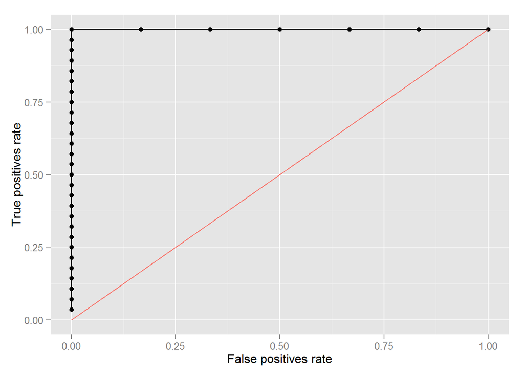

**Manhattan Plot**

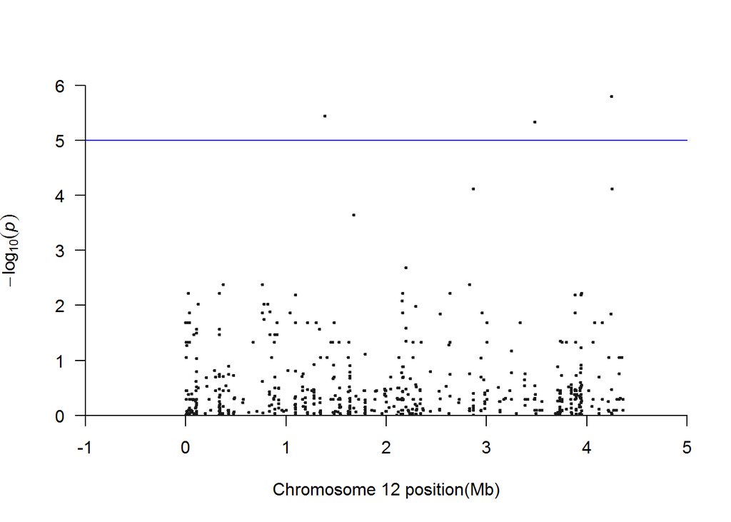

```r
manhattan(test.gwas, cex = .5)
```

**Q-Q Plot**

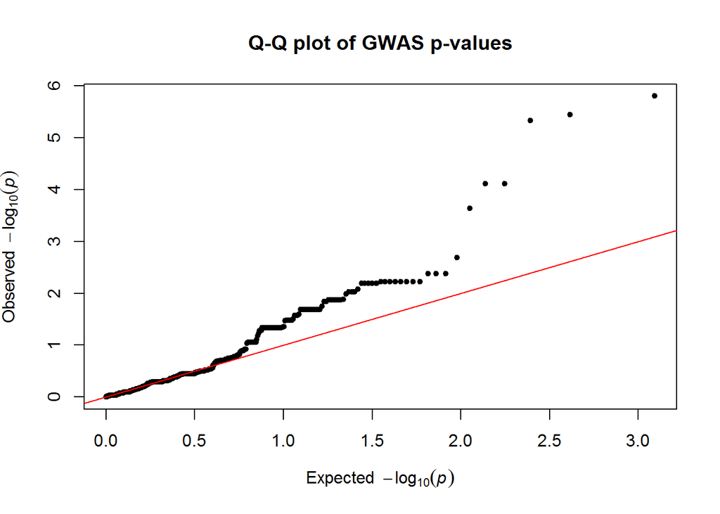

**Significant mutations**

|  | ps | allele1 | allele0 | af | p_lrt | bonferroni | holm | hochberg | fdr | BY |
| --- | --- | --- | --- | --- | --- | --- | --- | --- | --- | --- |
| 16 | 25899 | A | G | 0.029 | 0.005960452 | 1.0000000 | 1.0000000 | 0.9999699 | 0.174262 | 1.000000 |
| 64 | 122350 | G | A | 0.059 | 0.009505900 | 1.0000000 | 1.0000000 | 0.9999699 | 0.217932 | 1.000000 |
| 82 | 335845 | C | T | 0.029 | 0.005960452 | 1.0000000 | 1.0000000 | 0.9999699 | 0.174262 | 1.000000 |
| 112 | 374353 | A | G | 0.324 | 0.004180411 | 1.0000000 | 1.0000000 | 0.9999699 | 0.174262 | 1.000000 |
| 137 | 761158 | C | T | 0.324 | 0.004180411 | 1.0000000 | 1.0000000 | 0.9999699 | 0.174262 | 1.000000 |
| 141 | 781825 | G | A | 0.059 | 0.009505900 | 1.0000000 | 1.0000000 | 0.9999699 | 0.217932 | 1.000000 |
| 142 | 817530 | T | G | 0.059 | 0.009505900 | 1.0000000 | 1.0000000 | 0.9999699 | 0.217932 | 1.000000 |
| 185 | 1096512 | C | G | 0.118 | 0.006474991 | 1.0000000 | 1.0000000 | 0.9999699 | 0.174262 | 1.000000 |
| 186 | 1096571 | A | G | 0.118 | 0.006474991 | 1.0000000 | 1.0000000 | 0.9999699 | 0.174262 | 1.000000 |
| 222 | 1385345 | T | C | 0.029 | 0.000003564 | 0.0022060 | 0.0022025 | 0.0022025 | 0.000960 | 0.006726 |
| 283 | 1673431 | T | C | 0.235 | 0.000228213 | 0.1412640 | 0.1401229 | 0.1401229 | 0.023544 | 0.164952 |
| 337 | 2155175 | C | G | 0.176 | 0.008330007 | 1.0000000 | 1.0000000 | 0.9999699 | 0.214845 | 1.000000 |
| 349 | 2165855 | A | G | 0.029 | 0.005960452 | 1.0000000 | 1.0000000 | 0.9999699 | 0.174262 | 1.000000 |
| 360 | 2196976 | G | C | 0.353 | 0.002068306 | 1.0000000 | 1.0000000 | 0.9999699 | 0.174262 | 1.000000 |
| 408 | 2633638 | T | G | 0.029 | 0.005960452 | 1.0000000 | 1.0000000 | 0.9999699 | 0.174262 | 1.000000 |
| 418 | 2829304 | C | T | 0.324 | 0.004180411 | 1.0000000 | 1.0000000 | 0.9999699 | 0.174262 | 1.000000 |
| 422 | 2866873 | C | G | 0.353 | 0.000076221 | 0.0471806 | 0.0469519 | 0.0468757 | 0.009436 | 0.066111 |
| 471 | 3482714 | A | G | 0.324 | 0.000004652 | 0.0028799 | 0.0028706 | 0.0028706 | 0.000960 | 0.006726 |
| 533 | 3883975 | G | T | 0.118 | 0.006474991 | 1.0000000 | 1.0000000 | 0.9999699 | 0.174262 | 1.000000 |
| 534 | 3883976 | G | A | 0.118 | 0.006474991 | 1.0000000 | 1.0000000 | 0.9999699 | 0.174262 | 1.000000 |
| 572 | 3942660 | C | G | 0.118 | 0.006474991 | 1.0000000 | 1.0000000 | 0.9999699 | 0.174262 | 1.000000 |
| 582 | 3947016 | C | T | 0.029 | 0.005960452 | 1.0000000 | 1.0000000 | 0.9999699 | 0.174262 | 1.000000 |
| 583 | 3947022 | C | T | 0.029 | 0.005960452 | 1.0000000 | 1.0000000 | 0.9999699 | 0.174262 | 1.000000 |
| 584 | 3947037 | C | T | 0.029 | 0.005960452 | 1.0000000 | 1.0000000 | 0.9999699 | 0.174262 | 1.000000 |
| 587 | 3948891 | T | C | 0.029 | 0.005960452 | 1.0000000 | 1.0000000 | 0.9999699 | 0.174262 | 1.000000 |
| 605 | 4247607 | G | A | 0.176 | 0.000001576 | 0.0009754 | 0.0009754 | 0.0009754 | 0.000960 | 0.006726 |
| 608 | 4254217 | T | C | 0.353 | 0.000076221 | 0.0471806 | 0.0469519 | 0.0468757 | 0.009436 | 0.066111 |

## ‘RIF’ Details

**Manhattan Plot**

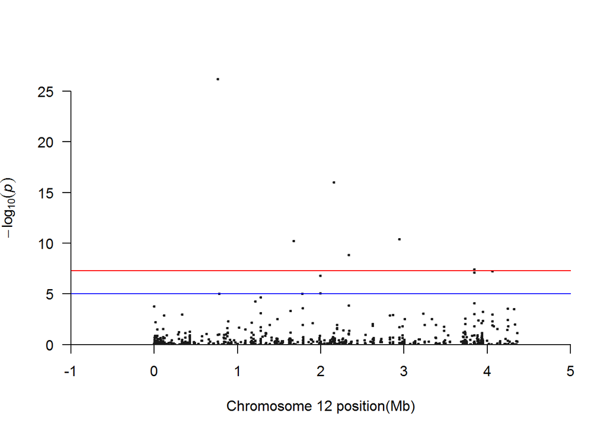

```r
manhattan(test.gwas, cex = .5)
```

**Q-Q Plot**

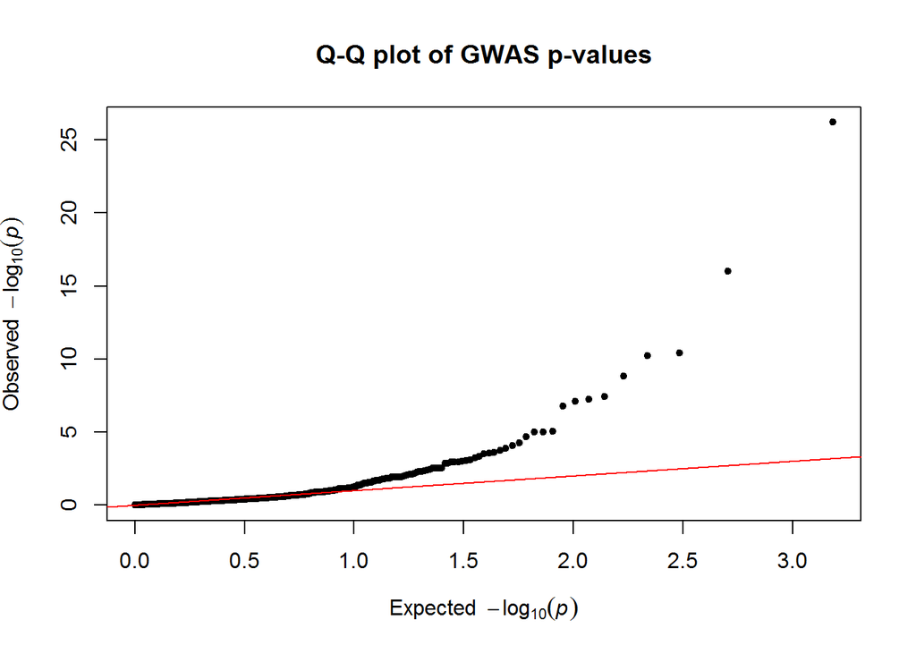

**Significant mutations**

|  | ps | allele1 | allele0 | af | p_lrt | bonferroni | holm | hochberg | fdr | BY |
| --- | --- | --- | --- | --- | --- | --- | --- | --- | --- | --- |
| 1 | 698 | A | G | 0.159 | 0.00017915670000000000 | 0.13705487550000001 | 0.13418836830000000 | 0.13418836830000000 | 0.00806205150000000 | 0.0581898315096651 |
| 25 | 14105 | G | C | 0.023 | 0.00595858999999999972 | 1.00000000000000000 | 1.00000000000000000 | 0.99979070000000003 | 0.11395803374999998 | 0.8225200227367973 |
| 180 | 119102 | G | A | 0.015 | 0.00136243200000000001 | 1.00000000000000000 | 1.00000000000000000 | 0.99979070000000003 | 0.03474201600000000 | 0.2507590105751730 |
| 382 | 333682 | T | C | 0.167 | 0.00113445100000000008 | 0.86785501500000006 | 0.83835928900000001 | 0.83835928900000001 | 0.03138087375000000 | 0.2264991430702933 |
| 797 | 761158 | C | T | 0.394 | 0.00000000000000000000 | 0.00000000000000000 | 0.00000000000000000 | 0.00000000000000000 | 0.00000000000000000 | 0.0000000000000000 |
| 830 | 781690 | G | A | 0.492 | 0.00000989257100000000 | 0.00756781681500000 | 0.00746889110500000 | 0.00746889110500000 | 0.00064291811250000 | 0.0046404189604702 |
| 927 | 888650 | T | C | 0.182 | 0.00486009500000000004 | 1.00000000000000000 | 1.00000000000000000 | 0.99979070000000003 | 0.09749685692307694 | 0.7037074468050436 |
| 1224 | 1169970 | A | G | 0.038 | 0.00709667500000000021 | 1.00000000000000000 | 1.00000000000000000 | 0.99979070000000003 | 0.13241357012195124 | 0.9557273772053637 |
| 1268 | 1212437 | C | A | 0.348 | 0.00005700591000000000 | 0.04360952115000000 | 0.04286844432000000 | 0.04286844432000000 | 0.00311496579642857 | 0.0224830286500338 |
| 1320 | 1276428 | C | T | 0.030 | 0.00083014510000000005 | 0.63506100150000000 | 0.61679780930000006 | 0.61679780930000006 | 0.02761134789130434 | 0.1992916668356369 |
| 1321 | 1276437 | T | C | 0.023 | 0.00002186717000000000 | 0.01672838505000000 | 0.01646597901000000 | 0.01646597901000000 | 0.00128679885000000 | 0.0092877859026739 |
| 1500 | 1481191 | C | A | 0.235 | 0.00303358699999999992 | 1.00000000000000000 | 1.00000000000000000 | 0.99979070000000003 | 0.06992178750000000 | 0.5046776287002890 |
| 1670 | 1638194 | T | C | 0.023 | 0.00046461560000000002 | 0.35543093400000003 | 0.34613862200000001 | 0.34613862200000001 | 0.01692528257142857 | 0.1221623728259364 |
| 1702 | 1673431 | T | C | 0.235 | 0.00000000006287214000 | 0.00000004809718710 | 0.00000004790857068 | 0.00000004790857068 | 0.00000001202429678 | 0.0000000867883073 |
| 1797 | 1779376 | C | G | 0.076 | 0.00001008499000000000 | 0.00771501735000000 | 0.00760408246000000 | 0.00760408246000000 | 0.00064291811250000 | 0.0046404189604702 |
| 1801 | 1784411 | G | C | 0.038 | 0.00024537149999999999 | 0.18770919749999998 | 0.18353788199999999 | 0.18353788199999999 | 0.01042828875000000 | 0.0752687284739667 |
| 1917 | 1905524 | C | T | 0.023 | 0.00767485400000000005 | 1.00000000000000000 | 1.00000000000000000 | 0.99979070000000003 | 0.13654100720930235 | 0.9855181654035912 |
| 1990 | 1993815 | T | A | 0.098 | 0.00000866395400000000 | 0.00662792481000000 | 0.00654994922400000 | 0.00654994922400000 | 0.00064291811250000 | 0.0046404189604702 |
| 1991 | 1994349 | C | T | 0.038 | 0.00000016285580000000 | 0.00012458468700000 | 0.00012328184060000 | 0.00012328184060000 | 0.00001384274300000 | 0.0000999133883977 |
| 2149 | 2155175 | C | G | 0.303 | 0.00000000000000009472 | 0.00000000000007246 | 0.00000000000007236 | 0.00000000000007236 | 0.00000000000003623 | 0.0000000000002615 |
| 2492 | 2339283 | C | A | 0.023 | 0.00013810569999999999 | 0.10565086049999999 | 0.10357927499999998 | 0.10357927499999998 | 0.00660317878125000 | 0.0476600603096040 |
| 2504 | 2339613 | G | A | 0.030 | 0.00000000144677400000 | 0.00000110678211000 | 0.00000110099501400 | 0.00000110099501400 | 0.00000022135642200 | 0.0000015976941973 |
| 2734 | 2626688 | C | A | 0.015 | 0.00930649700000000038 | 1.00000000000000000 | 1.00000000000000000 | 0.99979070000000003 | 0.15821044900000000 | 1.0000000000000000 |
| 2882 | 2828832 | T | G | 0.250 | 0.00132669800000000007 | 1.00000000000000000 | 0.97777642599999992 | 0.97777642599999992 | 0.03474201600000000 | 0.2507590105751730 |
| 2920 | 2866873 | C | G | 0.348 | 0.00114858100000000008 | 0.87866446500000006 | 0.84765277800000016 | 0.84765277800000016 | 0.03138087375000000 | 0.2264991430702933 |
| 3020 | 2944749 | T | C | 0.015 | 0.00000000003962640000 | 0.00000003031419600 | 0.00000003023494320 | 0.00000003023494320 | 0.00000001010473200 | 0.0000000729333784 |
| 3085 | 3007156 | C | G | 0.038 | 0.00306185699999999986 | 1.00000000000000000 | 1.00000000000000000 | 0.99979070000000003 | 0.06992178750000000 | 0.5046776287002890 |
| 3249 | 3232713 | A | G | 0.023 | 0.00089174540000000002 | 0.68218523100000006 | 0.66167508679999998 | 0.66167508679999998 | 0.02842438462500000 | 0.2051599586153308 |
| 3326 | 3336597 | A | T | 0.189 | 0.00310763500000000008 | 1.00000000000000000 | 1.00000000000000000 | 0.99979070000000003 | 0.06992178750000000 | 0.5046776287002890 |
| 3646 | 3735880 | G | A | 0.015 | 0.00898744200000000000 | 1.00000000000000000 | 1.00000000000000000 | 0.99979070000000003 | 0.15625893477272729 | 1.0000000000000000 |
| 3648 | 3735984 | G | C | 0.144 | 0.00283286900000000001 | 1.00000000000000000 | 1.00000000000000000 | 0.99979070000000003 | 0.06990789629032258 | 0.5045773654917750 |
| 3778 | 3842469 | T | C | 0.015 | 0.00000003849672000000 | 0.00002944999080000 | 0.00002925750720000 | 0.00002925750720000 | 0.00000490833180000 | 0.0000354270870678 |
| 3785 | 3842662 | C | A | 0.030 | 0.00000008063070000000 | 0.00006168248550000 | 0.00006111807060000 | 0.00006111807060000 | 0.00000771031068750 | 0.0000556510560361 |
| 3799 | 3842747 | A | C | 0.038 | 0.00099787529999999995 | 0.76337460449999994 | 0.73942559730000001 | 0.73942559730000001 | 0.03053498418000000 | 0.2203937278972343 |
| 3805 | 3843156 | G | A | 0.023 | 0.00008558095000000000 | 0.06546942675000000 | 0.06427129345000000 | 0.06427129345000000 | 0.00436462845000000 | 0.0315027749584322 |
| 3904 | 3895578 | A | C | 0.212 | 0.00400603600000000015 | 1.00000000000000000 | 1.00000000000000000 | 0.99979070000000003 | 0.08512826500000001 | 0.6144341048999900 |
| 3946 | 3930619 | A | C | 0.038 | 0.00755164100000000043 | 1.00000000000000000 | 1.00000000000000000 | 0.99979070000000003 | 0.13654100720930235 | 0.9855181654035912 |
| 3993 | 3946429 | G | C | 0.015 | 0.00059795319999999999 | 0.45743419800000001 | 0.44487718079999999 | 0.44487718079999999 | 0.02079246354545455 | 0.1500746987762177 |
| 4011 | 3947508 | C | G | 0.015 | 0.00457777099999999958 | 1.00000000000000000 | 1.00000000000000000 | 0.99979070000000003 | 0.09464850851351352 | 0.6831487944529322 |
| 4111 | 4060279 | G | A | 0.068 | 0.00109485799999999999 | 0.83756637000000000 | 0.81019492000000004 | 0.81019492000000004 | 0.03138087375000000 | 0.2264991430702933 |
| 4116 | 4060645 | A | G | 0.038 | 0.00497042799999999983 | 1.00000000000000000 | 1.00000000000000000 | 0.99979070000000003 | 0.09749685692307694 | 0.7037074468050436 |
| 4117 | 4060767 | T | C | 0.326 | 0.00000005972181000000 | 0.00004568718465000 | 0.00004532885379000 | 0.00004532885379000 | 0.00000652674066429 | 0.0000471083494768 |
| 4274 | 4247607 | G | A | 0.121 | 0.00028646230000000002 | 0.21914365950000000 | 0.21398733809999998 | 0.21398733809999998 | 0.01153387681578947 | 0.0832485811538195 |
| 4278 | 4248181 | G | A | 0.205 | 0.00365857200000000013 | 1.00000000000000000 | 1.00000000000000000 | 0.99979070000000003 | 0.07996593085714286 | 0.5771736937044712 |
| 4358 | 4322778 | C | G | 0.189 | 0.00030649749999999998 | 0.23447058750000002 | 0.22864713500000003 | 0.22864713500000003 | 0.01172352937500000 | 0.0846174449555252 |

## ‘RIF-nodup’ Details

**Manhattan Plot**

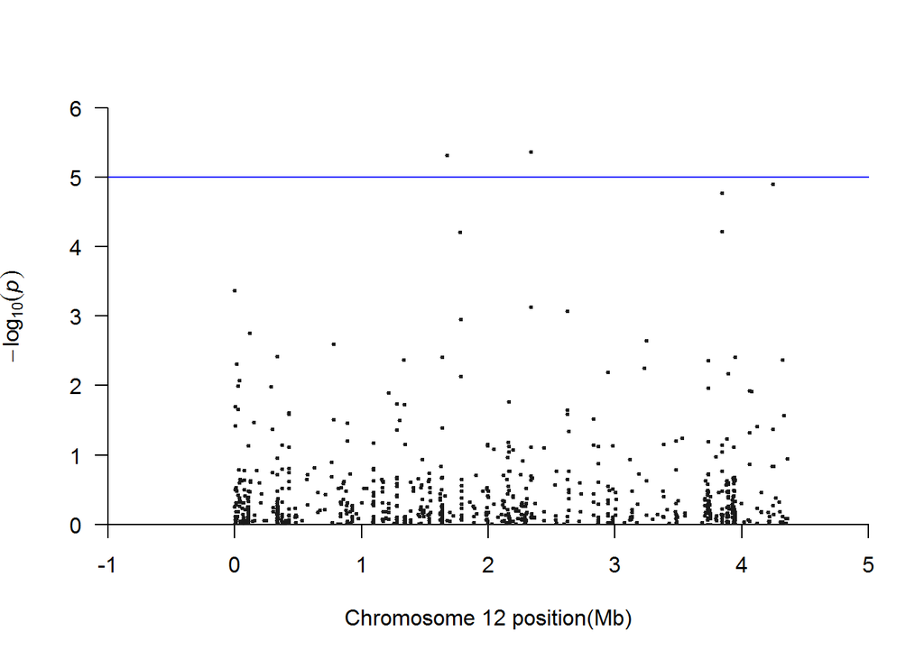

```r
manhattan(test.gwas, cex = .5)
```

**Q-Q Plot**

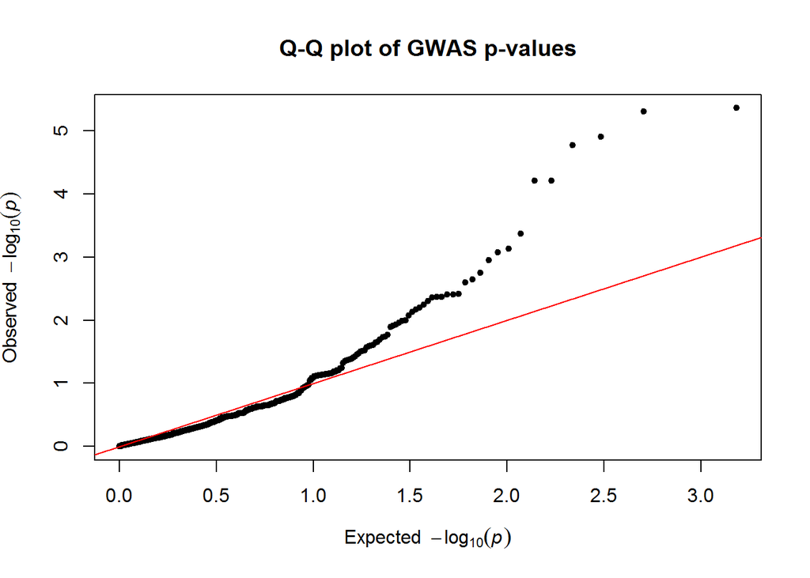

**Significant mutations**

|  | ps | allele1 | allele0 | af | p_lrt | bonferroni | holm | hochberg | fdr | BY |
| --- | --- | --- | --- | --- | --- | --- | --- | --- | --- | --- |
| 1 | 698 | A | G | 0.159 | 0.000428059 | 0.326609 | 0.324041 | 0.324041 | 0.046658 | 0.33665 |
| 18 | 14105 | G | C | 0.023 | 0.004942531 | 1.000000 | 1.000000 | 0.999228 | 0.188558 | 1.00000 |
| 31 | 35978 | A | G | 0.076 | 0.008447028 | 1.000000 | 1.000000 | 0.999228 | 0.257803 | 1.00000 |
| 81 | 119102 | G | A | 0.015 | 0.001755979 | 1.000000 | 1.000000 | 0.999228 | 0.121801 | 0.87881 |
| 107 | 333682 | T | C | 0.167 | 0.003786033 | 1.000000 | 1.000000 | 0.999228 | 0.176145 | 1.00000 |
| 188 | 781690 | G | A | 0.492 | 0.002533614 | 1.000000 | 1.000000 | 0.999228 | 0.148704 | 1.00000 |
| 283 | 1333675 | T | G | 0.371 | 0.004251937 | 1.000000 | 1.000000 | 0.999228 | 0.176145 | 1.00000 |
| 359 | 1638194 | T | C | 0.023 | 0.003897491 | 1.000000 | 1.000000 | 0.999228 | 0.176145 | 1.00000 |
| 365 | 1673431 | T | C | 0.235 | 0.000004861 | 0.003709 | 0.003704 | 0.003704 | 0.001855 | 0.01338 |
| 370 | 1779376 | C | G | 0.076 | 0.000061493 | 0.046919 | 0.046612 | 0.046612 | 0.007820 | 0.05642 |
| 371 | 1782438 | C | A | 0.023 | 0.007322313 | 1.000000 | 1.000000 | 0.999228 | 0.232789 | 1.00000 |
| 372 | 1784411 | G | C | 0.038 | 0.001117701 | 0.852806 | 0.842747 | 0.842747 | 0.085281 | 0.61531 |
| 482 | 2339283 | C | A | 0.023 | 0.000731276 | 0.557963 | 0.552845 | 0.552845 | 0.069745 | 0.50322 |
| 484 | 2339613 | G | A | 0.030 | 0.000004332 | 0.003305 | 0.003305 | 0.003305 | 0.001855 | 0.01338 |
| 504 | 2626610 | A | G | 0.053 | 0.000845743 | 0.645302 | 0.638536 | 0.638536 | 0.071700 | 0.51733 |
| 533 | 2944749 | T | C | 0.015 | 0.006379440 | 1.000000 | 1.000000 | 0.999228 | 0.221251 | 1.00000 |
| 563 | 3232713 | A | G | 0.023 | 0.005645661 | 1.000000 | 1.000000 | 0.999228 | 0.205126 | 1.00000 |
| 564 | 3246903 | C | T | 0.053 | 0.002237181 | 1.000000 | 1.000000 | 0.999228 | 0.142247 | 1.00000 |
| 615 | 3735880 | G | A | 0.015 | 0.004386305 | 1.000000 | 1.000000 | 0.999228 | 0.176145 | 1.00000 |
| 640 | 3842469 | T | C | 0.015 | 0.000016840 | 0.012849 | 0.012799 | 0.012799 | 0.003212 | 0.02318 |
| 641 | 3842662 | C | A | 0.030 | 0.000060960 | 0.046513 | 0.046269 | 0.046269 | 0.007820 | 0.05642 |
| 675 | 3895578 | A | C | 0.212 | 0.006764388 | 1.000000 | 1.000000 | 0.999228 | 0.224401 | 1.00000 |
| 714 | 3946429 | G | C | 0.015 | 0.003937839 | 1.000000 | 1.000000 | 0.999228 | 0.176145 | 1.00000 |
| 747 | 4247607 | G | A | 0.121 | 0.000012447 | 0.009497 | 0.009472 | 0.009472 | 0.003166 | 0.02284 |
| 758 | 4322778 | C | G | 0.189 | 0.004242027 | 1.000000 | 1.000000 | 0.999228 | 0.176145 | 1.00000 |

## ‘STM’ Details

**ROC learning curve**

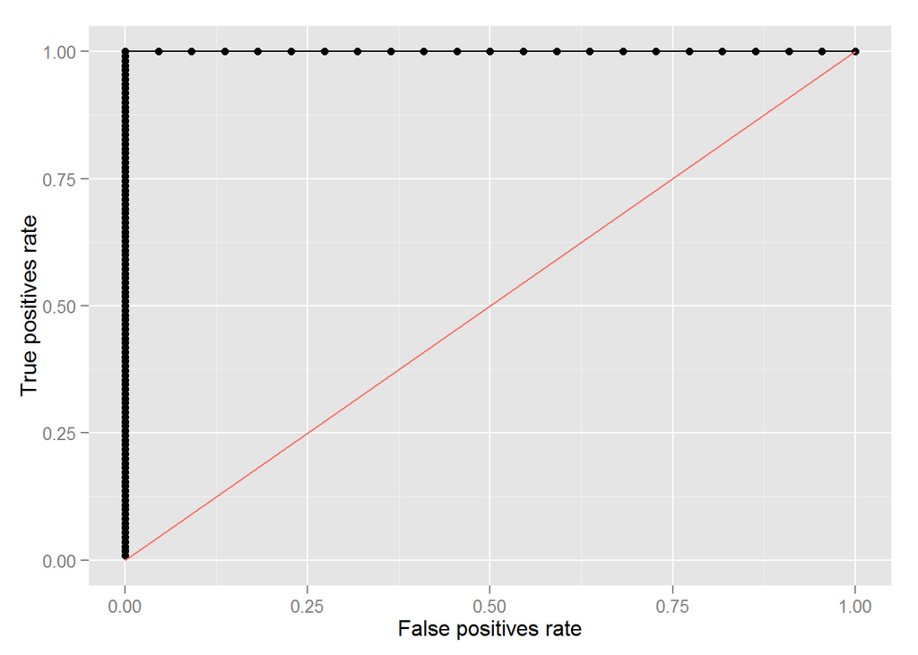

**Manhattan Plot**

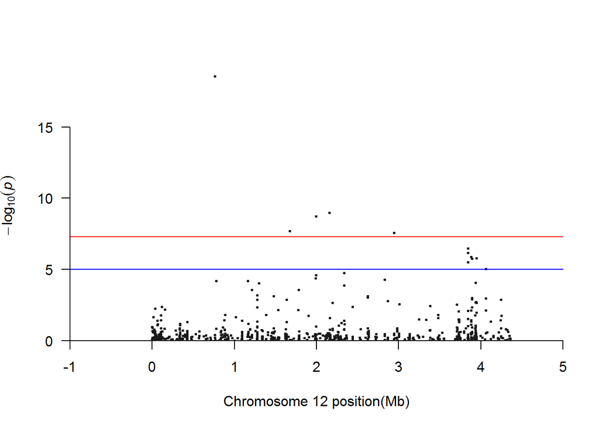

```r
manhattan(test.gwas, cex = .5)
```

**Q-Q Plot**

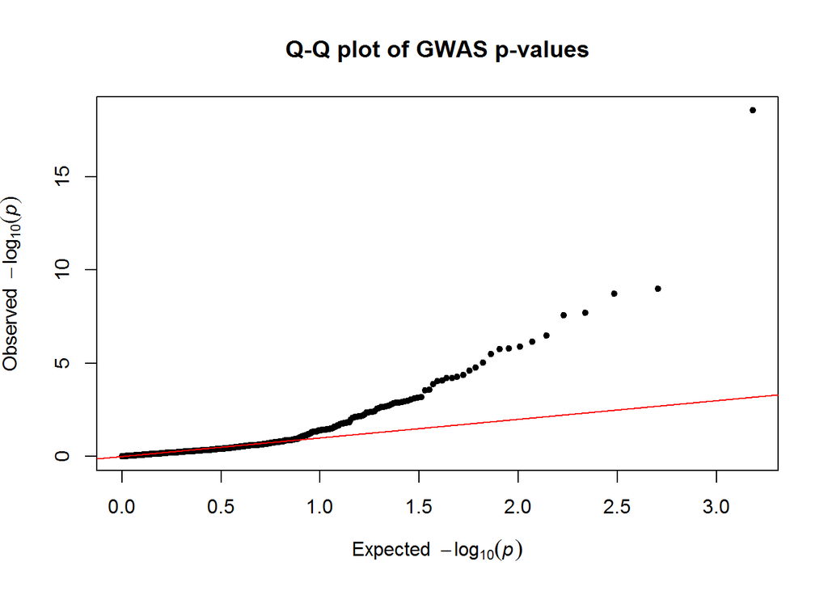

**Significant mutations**

|  | ps | allele1 | allele0 | af | p_lrt | bonferroni | holm | hochberg | fdr | BY |
| --- | --- | --- | --- | --- | --- | --- | --- | --- | --- | --- |
| 59 | 34879 | T | C | 0.023 | 0.00572296999999999997 | 1.0000000000000000000 | 1.0000000000000000000 | 0.9987785000000001245 | 0.0951754793478260669 | 0.686952335531670899 |
| 180 | 119102 | G | A | 0.015 | 0.00428690900000000021 | 1.0000000000000000000 | 1.0000000000000000000 | 0.9987785000000001245 | 0.0762671019767441893 | 0.550476490227976178 |
| 210 | 154189 | G | A | 0.015 | 0.00657892000000000025 | 1.0000000000000000000 | 1.0000000000000000000 | 0.9987785000000001245 | 0.1070824212765957573 | 0.772893605521136395 |
| 797 | 761158 | C | T | 0.394 | 0.00000000000000000028 | 0.0000000000000002155 | 0.0000000000000002155 | 0.0000000000000002155 | 0.0000000000000002155 | 0.000000000000001556 |
| 830 | 781690 | G | A | 0.492 | 0.00006553792000000000 | 0.0501365088000000000 | 0.0490223641600000121 | 0.0490223641600000121 | 0.0027853616000000003 | 0.020104029625398850 |
| 1218 | 1164813 | G | T | 0.038 | 0.00006378150000000000 | 0.0487928475000000000 | 0.0477723435000000016 | 0.0477723435000000016 | 0.0027853616000000003 | 0.020104029625398850 |
| 1268 | 1212437 | C | A | 0.348 | 0.00027808590000000000 | 0.2127357135000000066 | 0.2066178236999999807 | 0.2066178236999999807 | 0.0092493788478260862 | 0.066759657479744494 |
| 1318 | 1276419 | T | G | 0.023 | 0.00445769099999999974 | 1.0000000000000000000 | 1.0000000000000000000 | 0.9987785000000001245 | 0.0773679859999999997 | 0.558422390328581875 |
| 1321 | 1276437 | T | C | 0.023 | 0.00139609999999999995 | 1.0000000000000000000 | 1.0000000000000000000 | 0.9987785000000001245 | 0.0323641363636363658 | 0.233596081835476449 |
| 1333 | 1276943 | C | G | 0.023 | 0.00065694560000000002 | 0.5025633840000000019 | 0.4874536352000000128 | 0.4874536352000000128 | 0.0209401410000000024 | 0.151140596978155045 |
| 1354 | 1303100 | A | G | 0.167 | 0.00009337403000000001 | 0.0714311329500000036 | 0.0696570263800000006 | 0.0696570263800000006 | 0.0035715566474999998 | 0.025778584960074912 |
| 1500 | 1481191 | C | A | 0.235 | 0.00078105790000000002 | 0.5975092935000000383 | 0.5779828460000000501 | 0.5779828460000000501 | 0.0229811266730769251 | 0.165871911015281509 |
| 1553 | 1533472 | C | T | 0.038 | 0.00688972300000000037 | 1.0000000000000000000 | 1.0000000000000000000 | 0.9987785000000001245 | 0.1079594384693877557 | 0.779223691936442142 |
| 1670 | 1638194 | T | C | 0.023 | 0.00133641399999999996 | 1.0000000000000000000 | 0.9822642899999999289 | 0.9822642899999999289 | 0.0323641363636363658 | 0.233596081835476449 |
| 1702 | 1673431 | T | C | 0.235 | 0.00000002052256000000 | 0.0000156997584000000 | 0.0000156381907200000 | 0.0000156381907200000 | 0.0000039249396000000 | 0.000028329212981288 |
| 1797 | 1779376 | C | G | 0.076 | 0.00691504900000000037 | 1.0000000000000000000 | 1.0000000000000000000 | 0.9987785000000001245 | 0.1079594384693877557 | 0.779223691936442142 |
| 1801 | 1784411 | G | C | 0.038 | 0.00026899060000000003 | 0.2057778090000000337 | 0.2001290064000000313 | 0.2001290064000000313 | 0.0092493788478260862 | 0.066759657479744494 |
| 1989 | 1990926 | C | G | 0.015 | 0.00004178256000000000 | 0.0319636583999999974 | 0.0313787025599999991 | 0.0313787025599999991 | 0.0021309105600000001 | 0.015380368935694111 |
| 1990 | 1993815 | T | A | 0.098 | 0.00000000186648300000 | 0.0000014278594950000 | 0.0000014241265290000 | 0.0000014241265290000 | 0.0000004759531650000 | 0.000003435308553641 |
| 1991 | 1994349 | C | T | 0.038 | 0.00002490346000000000 | 0.0190511468999999996 | 0.0187274019200000010 | 0.0187274019200000010 | 0.0013607962071428572 | 0.009821879953586776 |
| 2149 | 2155175 | C | G | 0.303 | 0.00000000106620700000 | 0.0000008156483550000 | 0.0000008145821480000 | 0.0000008145821480000 | 0.0000004078241775000 | 0.000002943570898089 |
| 2250 | 2196976 | G | C | 0.379 | 0.00226976699999999979 | 1.0000000000000000000 | 1.0000000000000000000 | 0.9987785000000001245 | 0.0456939935526315746 | 0.329807591260283417 |
| 2492 | 2339283 | C | A | 0.023 | 0.00013074460000000001 | 0.1000196190000000040 | 0.0974047270000000243 | 0.0974047270000000243 | 0.0047628390000000005 | 0.034376957145171035 |
| 2504 | 2339613 | G | A | 0.030 | 0.00001783358000000000 | 0.0136426887000000007 | 0.0134286857399999997 | 0.0134286857399999997 | 0.0010494375923076923 | 0.007574572883377542 |
| 2576 | 2439409 | G | A | 0.197 | 0.00425476400000000029 | 1.0000000000000000000 | 1.0000000000000000000 | 0.9987785000000001245 | 0.0762671019767441893 | 0.550476490227976178 |
| 2733 | 2626610 | A | G | 0.053 | 0.00090756419999999999 | 0.6942866129999999414 | 0.6706899438000000213 | 0.6706899438000000213 | 0.0257143189999999994 | 0.185599396133326600 |
| 2734 | 2626688 | C | A | 0.015 | 0.00074174280000000004 | 0.5674332420000000043 | 0.5496314147999999955 | 0.5496314147999999955 | 0.0226973296800000029 | 0.163823536701362071 |
| 2882 | 2828832 | T | G | 0.250 | 0.00005298184000000000 | 0.0405311075999999978 | 0.0397363799999999948 | 0.0397363799999999948 | 0.0025331942249999999 | 0.018283949827659456 |
| 2920 | 2866873 | C | G | 0.348 | 0.00168963399999999997 | 1.0000000000000000000 | 1.0000000000000000000 | 0.9987785000000001245 | 0.0380167650000000010 | 0.274395313636055738 |
| 3020 | 2944749 | T | C | 0.015 | 0.00000002778374000000 | 0.0000212545611000000 | 0.0000211434261400000 | 0.0000211434261400000 | 0.0000042509122200000 | 0.000030682000213491 |
| 3085 | 3007156 | C | G | 0.038 | 0.00271799300000000014 | 1.0000000000000000000 | 1.0000000000000000000 | 0.9987785000000001245 | 0.0533144780769230844 | 0.384810304960454319 |
| 3353 | 3381652 | T | G | 0.265 | 0.00379127899999999983 | 1.0000000000000000000 | 1.0000000000000000000 | 0.9987785000000001245 | 0.0707397179268292736 | 0.510581241908890204 |
| 3602 | 3710566 | T | C | 0.015 | 0.00292883999999999983 | 1.0000000000000000000 | 1.0000000000000000000 | 0.9987785000000001245 | 0.0560140649999999879 | 0.404295234844558926 |
| 3629 | 3732260 | T | C | 0.023 | 0.00859723800000000010 | 1.0000000000000000000 | 1.0000000000000000000 | 0.9987785000000001245 | 0.1240922088679245472 | 0.895665914027800381 |
| 3778 | 3842469 | T | C | 0.015 | 0.00000068652830000000 | 0.0005251941494999999 | 0.0005210749797000000 | 0.0005210749797000000 | 0.0000750277356428571 | 0.000541531060128995 |
| 3785 | 3842662 | C | A | 0.030 | 0.00000033891410000000 | 0.0002592692865000000 | 0.0002575747160000000 | 0.0002575747160000000 | 0.0000432115477500000 | 0.000311889930601950 |
| 3799 | 3842747 | A | C | 0.038 | 0.00829402199999999985 | 1.0000000000000000000 | 1.0000000000000000000 | 0.9987785000000001245 | 0.1220178236538461553 | 0.880693530622241316 |
| 3805 | 3843156 | G | A | 0.023 | 0.00000316070600000000 | 0.0024179400900000000 | 0.0023863330299999999 | 0.0023863330299999999 | 0.0002198127354545454 | 0.001586552261515396 |
| 3860 | 3884024 | C | T | 0.091 | 0.00000129929400000000 | 0.0009939599100000000 | 0.0009848648520000001 | 0.0009848648520000001 | 0.0001242449887500000 | 0.000896768640250281 |
| 3863 | 3884039 | G | A | 0.023 | 0.00740240999999999989 | 1.0000000000000000000 | 1.0000000000000000000 | 0.9987785000000001245 | 0.1125128100000000048 | 0.812088766312019095 |
| 3876 | 3894804 | T | C | 0.045 | 0.00000183724200000000 | 0.0014054901300000000 | 0.0013889549520000001 | 0.0013889549520000001 | 0.0001405490130000000 | 0.001014446928963395 |
| 3879 | 3894911 | A | G | 0.386 | 0.00455105800000000019 | 1.0000000000000000000 | 1.0000000000000000000 | 0.9987785000000001245 | 0.0773679859999999997 | 0.558422390328581875 |
| 3897 | 3895383 | G | A | 0.038 | 0.00121839800000000009 | 0.9320744699999999883 | 0.8967409280000000482 | 0.8967409280000000482 | 0.0310691490000000008 | 0.224249193329846636 |
| 3904 | 3895578 | A | C | 0.212 | 0.00103352499999999998 | 0.7906466249999999363 | 0.7627414499999999320 | 0.7627414499999999320 | 0.0282373794642857175 | 0.203810203060754841 |
| 3953 | 3934721 | T | G | 0.045 | 0.00202959400000000002 | 1.0000000000000000000 | 1.0000000000000000000 | 0.9987785000000001245 | 0.0431288724999999984 | 0.311293201733681413 |
| 3954 | 3934878 | G | A | 0.061 | 0.00008687002000000000 | 0.0664555653000000052 | 0.0648919049399999948 | 0.0648919049399999948 | 0.0034976613315789470 | 0.025245227416675498 |
| 3978 | 3943198 | C | G | 0.045 | 0.00188603600000000001 | 1.0000000000000000000 | 1.0000000000000000000 | 0.9987785000000001245 | 0.0412233582857142872 | 0.297539686134263903 |
| 3993 | 3946429 | G | C | 0.015 | 0.00219528300000000013 | 1.0000000000000000000 | 1.0000000000000000000 | 0.9987785000000001245 | 0.0453889593243243308 | 0.327605931999004896 |
| 4011 | 3947508 | C | G | 0.015 | 0.00000160130700000000 | 0.0012249998550000001 | 0.0012121893989999999 | 0.0012121893989999999 | 0.0001361110950000000 | 0.000982415168725481 |
| 4111 | 4060279 | G | A | 0.068 | 0.00750085400000000038 | 1.0000000000000000000 | 1.0000000000000000000 | 0.9987785000000001245 | 0.1125128100000000048 | 0.812088766312019095 |
| 4112 | 4060380 | G | A | 0.076 | 0.00111654500000000004 | 0.8541569250000001778 | 0.8228936650000000519 | 0.8228936650000000519 | 0.0294536870689655200 | 0.212589201133421862 |
| 4117 | 4060767 | T | C | 0.326 | 0.00000964782200000000 | 0.0073805838299999997 | 0.0072744577879999984 | 0.0072744577879999984 | 0.0006150486525000000 | 0.004439264306265169 |
| 4274 | 4247607 | G | A | 0.121 | 0.00137072699999999997 | 1.0000000000000000000 | 1.0000000000000000000 | 0.9987785000000001245 | 0.0323641363636363658 | 0.233596081835476449 |

## ‘STM-nodup’ Details

**ROC learning curve**

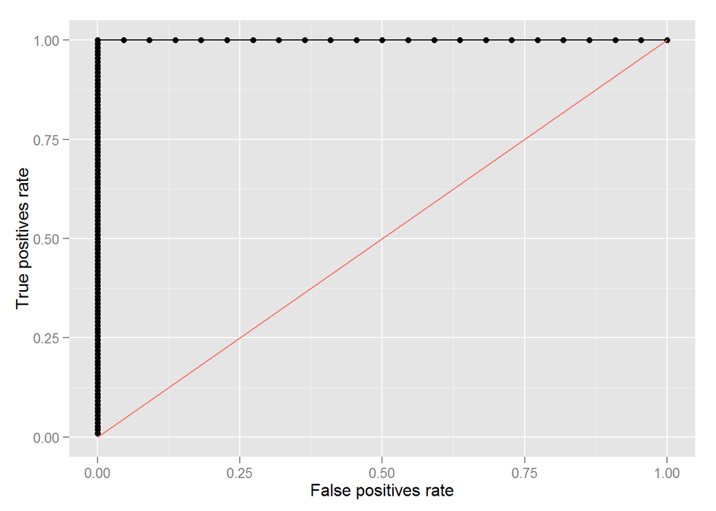

**Manhattan Plot**

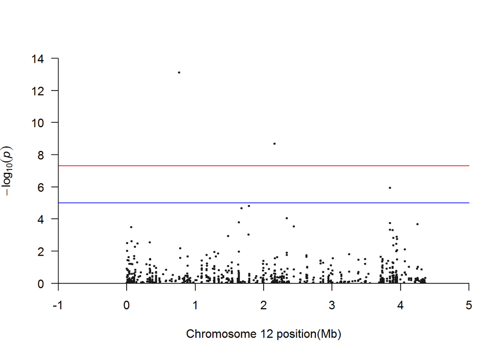

```r
manhattan(test.gwas, cex = .5)
```

**Q-Q Plot**

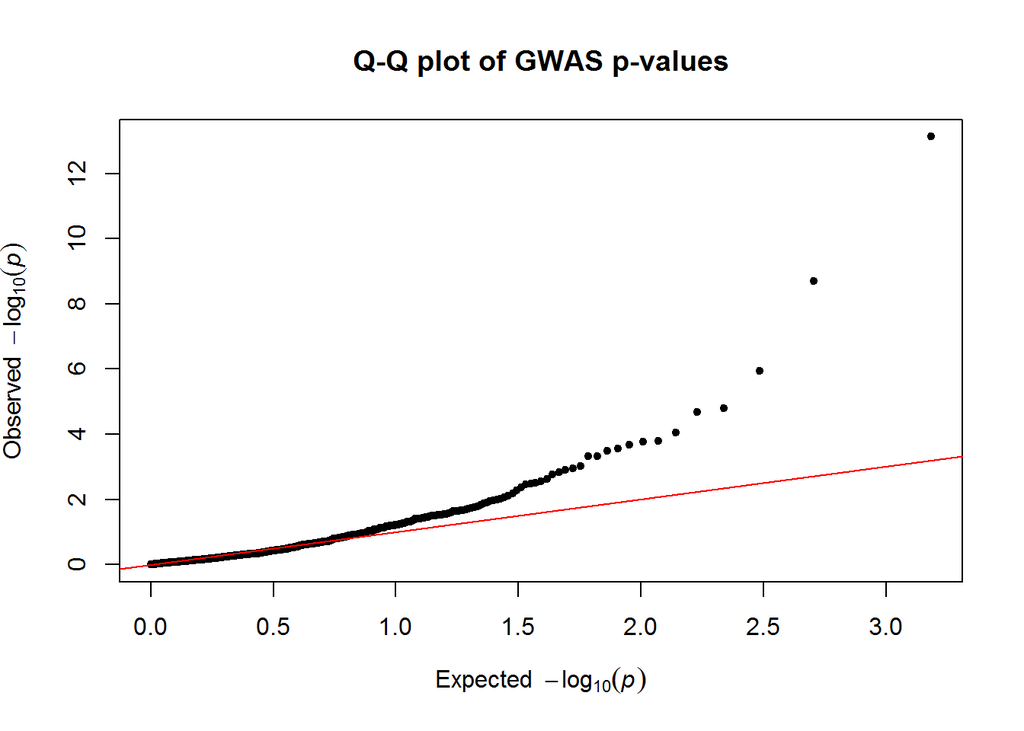

**Significant mutations**

|  | ps | allele1 | allele0 | af | p_lrt | bonferroni | holm | hochberg | fdr | BY |
| --- | --- | --- | --- | --- | --- | --- | --- | --- | --- | --- |
| 3 | 1769 | T | G | 0.015 | 0.00305252600000000 | 1.0000000000000 | 1.0000000000000 | 0.9988558000000 | 0.1111991614286 | 0.8026071859681 |
| 6 | 1977 | A | G | 0.061 | 0.00950637300000000 | 1.0000000000000 | 1.0000000000000 | 0.9988558000000 | 0.2507715636207 | 1.0000000000000 |
| 44 | 63865 | T | C | 0.030 | 0.00032385390000000 | 0.2477482335000 | 0.2445096945000 | 0.2445096945000 | 0.0225225666818 | 0.1625621419536 |
| 45 | 70023 | T | G | 0.015 | 0.00235789400000000 | 1.0000000000000 | 1.0000000000000 | 0.9988558000000 | 0.0949362584211 | 0.6852256998953 |
| 81 | 119102 | G | A | 0.015 | 0.00529391400000000 | 1.0000000000000 | 1.0000000000000 | 0.9988558000000 | 0.1619937684000 | 1.0000000000000 |
| 86 | 154189 | G | A | 0.015 | 0.00321646500000000 | 1.0000000000000 | 1.0000000000000 | 0.9988558000000 | 0.1118452602273 | 0.8072705623103 |
| 113 | 336069 | A | G | 0.015 | 0.00277555500000000 | 1.0000000000000 | 1.0000000000000 | 0.9988558000000 | 0.1061649787500 | 0.7662717393569 |
| 186 | 761158 | C | T | 0.394 | 0.00000000000007412 | 0.0000000000567 | 0.0000000000567 | 0.0000000000567 | 0.0000000000567 | 0.0000000004093 |
| 189 | 781690 | G | A | 0.492 | 0.00647411400000000 | 1.0000000000000 | 1.0000000000000 | 0.9988558000000 | 0.1904883542308 | 1.0000000000000 |
| 310 | 1481191 | C | A | 0.235 | 0.00114114400000000 | 0.8729751600000 | 0.8569991440000 | 0.8569991440000 | 0.0581983440000 | 0.4200608035686 |
| 360 | 1638194 | T | C | 0.023 | 0.00015828550000000 | 0.1210884075000 | 0.1201386945000 | 0.1201386945000 | 0.0166642818750 | 0.1202785363671 |
| 366 | 1673431 | T | C | 0.235 | 0.00002107387000000 | 0.0161215105500 | 0.0160372150700 | 0.0160372150700 | 0.0032243021100 | 0.0232721902753 |
| 371 | 1779376 | C | G | 0.076 | 0.00094079250000000 | 0.7197062625000 | 0.7074759600000 | 0.7074759600000 | 0.0514075901786 | 0.3710468744598 |
| 373 | 1784411 | G | C | 0.038 | 0.00001572285000000 | 0.0120279802500 | 0.0119808117000 | 0.0119808117000 | 0.0030069950625 | 0.0217037234304 |
| 430 | 2155175 | C | G | 0.303 | 0.00000000204203500 | 0.0000015621568 | 0.0000015601147 | 0.0000015601147 | 0.0000007810784 | 0.0000056376246 |
| 484 | 2339283 | C | A | 0.023 | 0.00009068845000000 | 0.0693766642500 | 0.0689232220000 | 0.0689232220000 | 0.0115627773750 | 0.0834571780191 |
| 493 | 2439409 | G | A | 0.197 | 0.00028485400000000 | 0.2179133100000 | 0.2153496240000 | 0.2153496240000 | 0.0217913310000 | 0.1572842693031 |
| 642 | 3842469 | T | C | 0.015 | 0.00017426700000000 | 0.1333142550000 | 0.1320943860000 | 0.1320943860000 | 0.0166642818750 | 0.1202785363671 |
| 643 | 3842662 | C | A | 0.030 | 0.00000114321800000 | 0.0008745617700 | 0.0008722753340 | 0.0008722753340 | 0.0002915205900 | 0.0021041212666 |
| 647 | 3843156 | G | A | 0.023 | 0.00046482500000000 | 0.3555911250000 | 0.3504780500000 | 0.3504780500000 | 0.0283183875000 | 0.2043948984015 |
| 660 | 3884024 | C | T | 0.091 | 0.00048122750000000 | 0.3681390375000 | 0.3623643075000 | 0.3623643075000 | 0.0283183875000 | 0.2043948984015 |
| 668 | 3894804 | T | C | 0.045 | 0.00150237200000000 | 1.0000000000000 | 1.0000000000000 | 0.9988558000000 | 0.0676067400000 | 0.4879682062956 |
| 677 | 3895578 | A | C | 0.212 | 0.00432307000000000 | 1.0000000000000 | 1.0000000000000 | 0.9988558000000 | 0.1377978562500 | 0.9945897812214 |
| 691 | 3934878 | G | A | 0.061 | 0.00344026000000000 | 1.0000000000000 | 1.0000000000000 | 0.9988558000000 | 0.1144260391304 | 0.8258979662085 |
| 707 | 3943198 | C | G | 0.045 | 0.00128168600000000 | 0.9804897900000 | 0.9612645000000 | 0.9612645000000 | 0.0612806118750 | 0.4423078269613 |
| 716 | 3946429 | G | C | 0.015 | 0.00855248900000000 | 1.0000000000000 | 1.0000000000000 | 0.9988558000000 | 0.2336662173214 | 1.0000000000000 |
| 723 | 3947508 | C | G | 0.015 | 0.00173612700000000 | 1.0000000000000 | 1.0000000000000 | 0.9988558000000 | 0.0737853975000 | 0.5325641802708 |
| 733 | 4060380 | G | A | 0.076 | 0.00777991500000000 | 1.0000000000000 | 1.0000000000000 | 0.9988558000000 | 0.2204309250000 | 1.0000000000000 |
| 749 | 4247607 | G | A | 0.121 | 0.00020838940000000 | 0.1594178910000 | 0.1577507758000 | 0.1577507758000 | 0.0177130990000 | 0.1278486308757 |